**Name: E.Teja Kumar Goud**

**Enroll : 4201**

**Batch: 106**

# Yield prediction of various farm processing units

### A new fast food chain is seeing rapid expansion over the past couple of years. They are now trying to optimize their supply chain to ensure that there are no shortages of ingredients. For this, they’ve tasked their data science team to come up with a model that could predict the output of each food processing farm over the next few years. These predictions could further increase the efficiency of their current supply chain management systems.

Problem Statement

So here, an XYZ fast food chain has observed its rapid growth within a few years since established. And now, as it has been one of the longest chains, they want to make the best use of the ingredients they have, without any shortage.

They wanted to know ‘what level of production for the required ingredients would be sufficient in the coming future.i.e for the next couple of years’. So, this would help them increase the efficiency of their current supply.

Here, we have the data of one whole year, where the yield of each plant at each processing farm and the records of the factors that effect its production are clearly explained.

Now, our goal is to build a model that could predict the yield of each processing farm for the next year. And also design a sourcing strategy for a particular ingredient.

For this the domain is agriculture. As agriculture is an important pillar of world’s economy, it is important to keep track of the information about crops and its cultivation parameters. Here’s one such problem.

- Yeild Data
- Farm Data
- Weather Data
- Test Data
- Weather Data

● Yeild Data

- date: The timestamp at which the yield of the food processing farm was measured
- farm_id: The farm identifier that recognizes the farm food processing plant
- ingredient_type: The type of ingredient being produced

● farm_data.csv:

- farm_id: The farm identifier that recognizes the farm food processing plant
- founding_year: They year when the operations commenced on the farm and food processing plant.
- num_processing_plants: The number of processing plants present on the farm
- farm_area: The area of the farm in square meters
- farming_company: The company that owns the farms

● deidentified_location: The location at which the farm is present For each location where the farms are present, the weather data is also provided by timestamp

- time_stamp: The timestamp at which the yield of the food processing farm was measured.
- deidentified_location: The location at which the farm is present.
- temp_obs : Observed daily weather temperatures in C` and it's effect
- cloudiness : the state of the sky when it is covered by clouds and overcast weather, measured in Oktas in the range 0 to 9
- wind_direction : Wind direction is usually the direction from which it originates,Reported in degrees
- dew_temp : Temperature to which the air have to be cooled in order to reach saturation.
- pressure_sea_level : It is the pressure within the atmosphere of Earth, Data points available in Millibars.
- precipitation : Condensation from atmospheric water vapor - includes Rain , Data present in mm/day.
- wind_speed : Quantity caused by air moving from high to low pressure, usually due to changes in temperature , Measured in Km/hr

● yield: The yield of the plant in tonnes....! [''Target'']

## Identify Error Metrics

##### Error Metrics for Regression

- Root Mean Squared Error (RMSE):

$$RMSE = \sqrt{\dfrac{1}{n}\times\sum_{i = 1}^{n}(y_{i} - \hat{y_{i}})^2}$$

```python
# Importing Library's requried
# Read the data files
# Performing steps like shape,missing values count,and describe function for the datasets
# Drop the yeild and checked for the duplicates and that duplicates are taken avg of there yeild rather droping duplicate records
# And concat them with the orignal data
# Drop duplicates in farm data and weather data
# Drop the attributes which are >40%
# Imputation for the weather data w.r.t location for each day and impute the avg of each day temprature for the missing values
# Merged 3 datasets and checked for missing values and again imputed with respeted location and day of the year
#
# visualization part

# Train-valid split
# Type convertion, Standardization , creating Dummies for catergorical attributes

# Model Buliding for the train data and evaluate the error metric for the validation data
# Get predictions and scores

# Test Preprocessing
# All train operation is done for the testdata but there are duplicates in the test data
# and if i drop the records the prediction file shape and smaple submission file shape will not be same when subbmitting the predictions. I faced an issue with that
```

```python
import pandas as pd
import numpy as np
import matplotlib.pyplot as plt
import seaborn as sns
%matplotlib inline
import warnings
from IPython.display import Image
warnings.filterwarnings('ignore')
import os
import sklearn
```

I have to build the model according to the problem statement but with the vast datasets given to me, to work with them I need high computational power that my local machine can't handle as well as the insofe iLab. so I used Microsoft Azure cloud and created a compute engine with a RAM of 32GB and 150GB storage and worked in that environment.

```python
# Creating python paltform in azure
```

[figure not shown]

```python
from IPython.display import Image
# Azure platform
Image('Azure Platform.png',height=600 , width=950)
```

[figure not shown]

```python
# We have a Machine learnig Workspace in azure
Image('Azure machine learning platform.png',height=700 , width=950)
```

[figure not shown]

```python
# Create a cluster and Launch Studio
Image('Create a cluster.png',height=700 , width=950)
```

[figure not shown]

```python
# Compute engine with 32GB RAM & 150GB Storage
Image('Created_compute engine.png',height=700 , width=950)
```

[figure not shown]

```python
# create notebook and import the datasets into the enivironment
Image('create Notebook in azure.png',height=700 , width=950)
```

# Data PreProcessing

## Data optimize function referred from github and link is here

● https://gist.github.com/enamoria/fa9baa906f23d1636c002e7186516a7b

```python
def reduce_mem_usage(df):
    """ iterate through all the columns of a dataframe and modify the data type
        to reduce memory usage.
    """
    start_mem = df.memory_usage().sum() / 1024**2
    print('Memory usage of dataframe is {:.2f} MB'.format(start_mem))

    for col in df.columns:
        col_type = df[col].dtype

        if col_type != object:
            c_min = df[col].min()
            c_max = df[col].max()
            if str(col_type)[:3] == 'int':
                if c_min > np.iinfo(np.int8).min and c_max < np.iinfo(np.int8).max:
                    df[col] = df[col].astype(np.int8)
                elif c_min > np.iinfo(np.int16).min and c_max < np.iinfo(np.int16).max:
                    df[col] = df[col].astype(np.int16)
                elif c_min > np.iinfo(np.int32).min and c_max < np.iinfo(np.int32).max:
                    df[col] = df[col].astype(np.int32)
                elif c_min > np.iinfo(np.int64).min and c_max < np.iinfo(np.int64).max:
                    df[col] = df[col].astype(np.int64)
            else:
                if c_min > np.finfo(np.float16).min and c_max < np.finfo(np.float16).max:
                    df[col] = df[col].astype(np.float16)
                elif c_min > np.finfo(np.float32).min and c_max < np.finfo(np.float32).max:
                    df[col] = df[col].astype(np.float32)
                else:
                    df[col] = df[col].astype(np.float64)
        else:
            df[col] = df[col].astype('category')

    end_mem = df.memory_usage().sum() / 1024**2
    print('Memory usage after optimization is: {:.2f} MB'.format(end_mem))
    print('Decreased by {:.1f}%'.format(100 * (start_mem - end_mem) / start_mem))

    return df


def import_data(file):
    """create a dataframe and optimize its memory usage"""
    df = pd.read_csv(file, keep_date_col=True)
    df = reduce_mem_usage(df)
    return df
```

- Yeild Data
- Farm Data
- Weather Data
- Test Data
- Weather Data

```python
print('-' * 80)
print('train_data')
train_data = import_data('train_data.csv')

print('-' * 80)
print('farm_data')
farm_data = import_data("farm_data-1646897931981.csv")

print('-' * 80)
print('train_weather')
train_weather = import_data('train_weather-1646897968670.csv')

print('-' * 80)
print('test_data')
test_data = import_data('test_data-1664552867678.csv')

print('-' * 80)
print('test_weather')
test_weather = import_data('test_weather-1646897984996-1664552604982.csv')
```

```
--------------------------------------------------------------------------------
train_data
Memory usage of dataframe is 616.95 MB
Memory usage after optimization is: 173.95 MB
Decreased by 71.8%
--------------------------------------------------------------------------------
farm_data
Memory usage of dataframe is 0.07 MB
Memory usage after optimization is: 0.07 MB
Decreased by -2.6%
--------------------------------------------------------------------------------
train_weather
Memory usage of dataframe is 9.60 MB
Memory usage after optimization is: 2.65 MB
Decreased by 72.4%
--------------------------------------------------------------------------------
test_data
Memory usage of dataframe is 636.26 MB
Memory usage after optimization is: 179.38 MB
Decreased by 71.8%
--------------------------------------------------------------------------------
test_weather
Memory usage of dataframe is 9.53 MB
Memory usage after optimization is: 2.63 MB
Decreased by 72.4%
```

```python
print(train_data.shape)
print(farm_data.shape)
print(train_weather.shape)
print(test_data.shape)
print(test_weather.shape)
```

```
(20216100, 4)
(1449, 6)
(139773, 9)
(20848800, 4)
(138825, 9)
```

```python
print(train_data.describe().T)
print('-'*70)
print(farm_data.describe().T)
print('-'*78)
print(train_weather.describe().T)
```

```
            count         mean          std  min        25%        50%  \
yield  20216100.0  1988.706177  153215.9375  0.0  18.299999  78.775002

              75%         max
yield  267.984009  21904700.0
----------------------------------------------------------------------
                             count         mean           std         min  \
operations_commencing_year   675.0          inf     31.062500  1900.00000
num_processing_plants        355.0     7.742188      3.333984     5.00000
farm_area                   1449.0  8557.459961  10290.857422    26.29155

                                    25%          50%           75%        max
operations_commencing_year  1949.000000  1970.000000   1995.000000   2017.000
num_processing_plants          5.000000     7.000000      9.000000     30.000
farm_area                   2137.883789  5357.994629  10746.647461  81290.125
------------------------------------------------------------------------------
                       count  mean  std        min          25%          50%  \
temp_obs            139718.0   NaN  0.0  -28.90625     7.199219    15.000000
cloudiness           70600.0   NaN  0.0    0.00000     0.000000     2.000000
wind_direction      133505.0   NaN  NaN    0.00000    80.000000   190.000000
dew_temp            139660.0   NaN  0.0  -35.00000     0.600098     8.296875
pressure_sea_level  129155.0   NaN  NaN  968.00000  1012.000000  1016.500000
precipitation        89484.0   NaN  NaN   -1.00000     0.000000     0.000000
wind_speed          139469.0   NaN  0.0    0.00000     2.099609     3.099609

                            75%         max
temp_obs              22.203125    47.18750
cloudiness             4.000000     9.00000
wind_direction       280.000000   360.00000
dew_temp              14.398438    26.09375
pressure_sea_level  1021.000000  1046.00000
precipitation          0.000000   343.00000
wind_speed             5.000000    19.00000
```

```python
# Defined Funtion For finding data types ,null values,Number of Unique values
def inspect_data(data) :
      return pd.DataFrame({"Data type": data.dtypes,
                           "NUll Values": data.isnull().sum(),
                           "No of Levels": data.apply(lambda x: str(x.nunique()),axis=0)
                          })
```

```python
#finding data types ,null values,Number of Unique values for Train data
inspect_data(train_data)
```

|  | Data type | NUll Values | No of Levels |
| --- | --- | --- | --- |
| date | category | 0 | 8784 |
| farm_id | category | 0 | 1434 |
| ingredient_type | category | 0 | 4 |
| yield | float32 | 0 | 1688175 |

```python
#finding data types ,null values,Number of Unique values for farm data
inspect_data(farm_data)
```

|  | Data type | NUll Values | No of Levels |
| --- | --- | --- | --- |
| farm_id | category | 0 | 1434 |
| operations_commencing_year | float16 | 774 | 116 |
| num_processing_plants | float16 | 1094 | 18 |
| farm_area | float32 | 0 | 1397 |
| farming_company | category | 0 | 16 |
| deidentified_location | category | 0 | 16 |

```python
#finding data types ,null values,Number of Unique values for weather data
inspect_data(train_weather)
```

|  | Data type | NUll Values | No of Levels |
| --- | --- | --- | --- |
| timestamp | category | 0 | 8784 |
| deidentified_location | category | 0 | 16 |
| temp_obs | float16 | 55 | 619 |
| cloudiness | float16 | 69173 | 10 |
| wind_direction | float16 | 6268 | 43 |
| dew_temp | float16 | 113 | 522 |
| pressure_sea_level | float16 | 10618 | 133 |
| precipitation | float16 | 50289 | 128 |
| wind_speed | float16 | 304 | 58 |

```python
# Convert Date and timestamp into object
train_data['date'] = train_data['date'].astype("object")
train_weather['timestamp'] = train_weather['timestamp'].astype("object")
test_data['date'] = test_data['date'].astype("object")
test_weather['timestamp'] = test_weather['timestamp'].astype("object")
```

```python
## Coverting Timestamp into DateTime Format
train_data['date'] = pd.to_datetime(train_data['date'])
train_weather['timestamp'] = pd.to_datetime(train_weather['timestamp'])
test_data['date'] = pd.to_datetime(test_data['date'])
test_weather['timestamp'] = pd.to_datetime(test_weather['timestamp'])
```

```python
train_weather.dtypes #Check dtypes
```

```
timestamp                datetime64[ns]
deidentified_location          category
temp_obs                        float16
cloudiness                      float16
wind_direction                  float16
dew_temp                        float16
pressure_sea_level              float16
precipitation                   float16
wind_speed                      float16
dtype: object
```

```python
#Using GroupBy some analysis
train_data.groupby('farm_id')['date'].nunique().reset_index(name='counts').sort_values(by = ['counts'],ascending=True)
```

|  | farm_id | counts |
| --- | --- | --- |
| 405 | fid_19864 | 479 |
| 406 | fid_20058 | 1012 |
| 1116 | fid_73322 | 1685 |
| 247 | fid_118770 | 2327 |
| 963 | fid_60652 | 2657 |
| ... | ... | ... |
| 557 | fid_30973 | 8784 |
| 558 | fid_31213 | 8784 |
| 1048 | fid_68361 | 8784 |
| 1064 | fid_69323 | 8784 |
| 716 | fid_43164 | 8784 |

1434 rows × 2 columns

```python
#Using GroupBy some analysis
train_data.groupby('farm_id')['ingredient_type'].nunique().reset_index(name='counts').sort_values(by = ['counts'],ascending=False)
```

|  | farm_id | counts |
| --- | --- | --- |
| 1144 | fid_75385 | 4 |
| 1053 | fid_68690 | 4 |
| 1207 | fid_81195 | 4 |
| 999 | fid_63700 | 4 |
| 1167 | fid_77519 | 4 |
| ... | ... | ... |
| 573 | fid_32291 | 1 |
| 574 | fid_32463 | 1 |
| 577 | fid_32688 | 1 |
| 578 | fid_32697 | 1 |
| 717 | fid_43214 | 1 |

1434 rows × 2 columns

```python
# Outcome of the yeild is zero count
len(train_data.loc[train_data['yield']==0,:])
```

```
1873976
```

```python
# Outcome of the yeild is >500 count
len(train_data.loc[train_data['yield']>=500,:])
```

```
3113966
```

```python
# Outcome of the yeild is >1000 count
len(train_data.loc[train_data['yield']>=1000,:])
```

```
1619472
```

```python
duplicateRowsDF = train_weather[train_weather.duplicated()]

print("Duplicate Rows :")
print(len(duplicateRowsDF))
```

```
Duplicate Rows :
0
```

```python
duplicateRowsDF = train_weather[train_weather[['timestamp','deidentified_location']].duplicated()]

print("Duplicate Rows  :")
print(len(duplicateRowsDF))
```

```
Duplicate Rows  :
0
```

```python
duplicateRowsDF = farm_data[farm_data.duplicated()]

print("Duplicate Rows :")
print(len(duplicateRowsDF))
```

```
Duplicate Rows :
0
```

```python
duplicateRowsDF = farm_data[farm_data['farm_id'].duplicated()]

print("Duplicate Rows with farm_Id's are :")
print(len(duplicateRowsDF))
```

```
Duplicate Rows with farm_Id's are :
15
```

```python
duplicateRowsDF = train_data[train_data.duplicated()]

print("Duplicate Rows in train data are :")
print(len(duplicateRowsDF))
```

```
Duplicate Rows in train data are :
117
```

```python
train_data.drop_duplicates(inplace=True)
```

```python
train_data.shape
```

```
(20215983, 4)
```

## The records that are duplicate except for yield, i.e mutiple similar records having different yields in train_data

```python
train_data.loc[train_data.duplicated(subset=['date', 'farm_id', 'ingredient_type'],keep=False),:].sort_values(by = ['date','farm_id','ingredient_type'])
```

|  | date | farm_id | ingredient_type | yield |
| --- | --- | --- | --- | --- |
| 1483 | 2016-01-01 00:00:00 | fid_122174 | ing_w | 69.516998 |
| 1598 | 2016-01-01 00:00:00 | fid_122174 | ing_w | 39.519001 |
| 695 | 2016-01-01 00:00:00 | fid_18990 | ing_w | 129.789993 |
| 747 | 2016-01-01 00:00:00 | fid_18990 | ing_w | 354.412994 |
| 669 | 2016-01-01 00:00:00 | fid_26064 | ing_w | 7.770000 |
| ... | ... | ... | ... | ... |
| 20215484 | 2016-12-31 23:00:00 | fid_73431 | ing_w | 107.867996 |
| 20214247 | 2016-12-31 23:00:00 | fid_81333 | ing_w | 42.320000 |
| 20214568 | 2016-12-31 23:00:00 | fid_81333 | ing_w | 391.625000 |
| 20214316 | 2016-12-31 23:00:00 | fid_97094 | ing_w | 15.140000 |
| 20215920 | 2016-12-31 23:00:00 | fid_97094 | ing_w | 2.400000 |

270902 rows × 4 columns

```python
#count of the Duplicate records i.e "keep = False" considers all are unique and we are getting the total count
train_data.duplicated(subset=['date', 'farm_id', 'ingredient_type'],keep=False).sum()
```

```
270902
```

```python
#duplicate records in train data
train_data.duplicated(subset=['date', 'farm_id', 'ingredient_type']).sum()
```

```
135451
```

### Droping the dupilcated rows with similar records into another variable

```python
#Dropping the Duplicate in one variable insted of droping them perment...!
dropped_dup_train = train_data.loc[train_data.duplicated(subset=['date', 'farm_id', 'ingredient_type'],keep=False),:].sort_values(by = ['date','farm_id','ingredient_type'])
```

```python
train_data2 = train_data.copy()
```

```python
train_data2.drop_duplicates(subset=['date', 'farm_id', 'ingredient_type'],keep=False,inplace=True)
```

```python
train_data2.shape
```

```
(19945081, 4)
```

## Taking the avg of the yield value in the duplicated rows

## Often, it's better to mark bad rows in a dataframe instead of deleting them.

```python
#Taking the mean of the yield of the duplicated records in the dropped duplicated records of train_data firs

dropped_dup_traintempdf = pd.DataFrame(((dropped_dup_train['yield'] + dropped_dup_train['yield'].shift(-1)) / 2)[::2])
```

```python
dropped_dup_traintempdf.head()
```

|  | yield |
| --- | --- |
| 1483 | 54.517998 |
| 695 | 242.101501 |
| 669 | 545.335022 |
| 783 | 65.803757 |
| 64 | 1.550000 |

```python
# Type of the variable
type(dropped_dup_traintempdf)
```

```
pandas.core.frame.DataFrame
```

```python
# Mergeing the two DF of avg and orignal yeild
dropped_dup_traintempdf_merge = pd.merge(dropped_dup_train, dropped_dup_traintempdf, left_index=True, right_index=True)
```

```python
dropped_dup_train.shape
```

```
(270902, 4)
```

```python
#Here we got avg yeild and orignal yead , drop the yeild_x
dropped_dup_traintempdf_merge.head()
```

|  | date | farm_id | ingredient_type | yield_x | yield_y |
| --- | --- | --- | --- | --- | --- |
| 1483 | 2016-01-01 | fid_122174 | ing_w | 69.516998 | 54.517998 |
| 695 | 2016-01-01 | fid_18990 | ing_w | 129.789993 | 242.101501 |
| 669 | 2016-01-01 | fid_26064 | ing_w | 7.770000 | 545.335022 |
| 783 | 2016-01-01 | fid_29387 | ing_w | 0.162500 | 65.803757 |
| 64 | 2016-01-01 | fid_40459 | ing_w | 0.000000 | 1.550000 |

```python
dropped_dup_traintempdf_merge.isnull().sum()
```

```
date               0
farm_id            0
ingredient_type    0
yield_x            0
yield_y            0
dtype: int64
```

```python
dropped_dup_traintempdf_merge.duplicated().sum()
```

```
0
```

```python
# Drop the Yeild_x :i.e Orignal and stored Avg of the yeild
dropped_dup_traintempdf_merge.drop("yield_x",axis = 1, inplace=True)
```

```python
dropped_dup_traintempdf_merge.shape
```

```
(135451, 4)
```

```python
## Rename the yeild_y to yeild
dropped_dup_traintempdf_merge.rename({'yield_y': 'yield'}, axis=1, inplace = True)
```

```python
#Bottom 10 Records
dropped_dup_traintempdf_merge[-10:-1]
```

|  | date | farm_id | ingredient_type | yield |
| --- | --- | --- | --- | --- |
| 20214281 | 2016-12-31 23:00:00 | fid_54932 | ing_w | 36.274002 |
| 20214597 | 2016-12-31 23:00:00 | fid_59158 | ing_w | 12.300000 |
| 20214903 | 2016-12-31 23:00:00 | fid_63700 | ing_w | 37.754551 |
| 20214904 | 2016-12-31 23:00:00 | fid_63700 | ing_x | 45.554050 |
| 20213971 | 2016-12-31 23:00:00 | fid_68761 | ing_w | 15.085000 |
| 20214297 | 2016-12-31 23:00:00 | fid_68792 | ing_w | 303.235840 |
| 20214598 | 2016-12-31 23:00:00 | fid_71910 | ing_w | 22.299999 |
| 20214206 | 2016-12-31 23:00:00 | fid_73431 | ing_w | 65.319000 |
| 20214247 | 2016-12-31 23:00:00 | fid_81333 | ing_w | 216.972504 |

```python
#Adding the Avg data frame to the orignal train Data Using concat
train_data2_combined_02= pd.concat([train_data2, dropped_dup_traintempdf_merge])
```

```python
train_data2_combined_02.shape
```

```
(20080532, 4)
```

```python
#Any dupilcates in Farm Data Droping the Duplicates
farm_data.drop_duplicates(subset="farm_id",
                     keep='first', inplace=True)
```

```python
farm_data
```

|  | farm_id | operations_commencing_year | num_processing_plants | farm_area | farming_company | deidentified_location |
| --- | --- | --- | --- | --- | --- | --- |
| 0 | fid_110884 | 2008.0 | NaN | 690.455078 | Obery Farms | location 7369 |
| 1 | fid_90053 | 2004.0 | NaN | 252.696167 | Obery Farms | location 7369 |
| 2 | fid_17537 | 1991.0 | NaN | 499.446533 | Obery Farms | location 7369 |
| 3 | fid_110392 | 2002.0 | NaN | 2200.407471 | Obery Farms | location 7369 |
| 4 | fid_62402 | 1975.0 | NaN | 10833.139648 | Obery Farms | location 7369 |
| ... | ... | ... | ... | ... | ... | ... |
| 1444 | fid_41664 | 1914.0 | NaN | 1822.663940 | Sanderson Farms | location 5150 |
| 1445 | fid_14529 | NaN | NaN | 399.297089 | Obery Farms | location 5150 |
| 1446 | fid_46454 | 1997.0 | NaN | 1046.552246 | Sanderson Farms | location 5150 |
| 1447 | fid_24103 | 2001.0 | NaN | 2766.186768 | Dole Food Company | location 5150 |
| 1448 | fid_34139 | 2001.0 | NaN | 8572.252930 | Wayne Farms | location 5150 |

1434 rows × 6 columns

```python
farm_data2 =farm_data.copy()
```

```python
farm_data2.nunique()
```

```
farm_id                       1434
operations_commencing_year     116
num_processing_plants           18
farm_area                     1382
farming_company                 16
deidentified_location           16
dtype: int64
```

```python
farm_data2.shape
```

```
(1434, 6)
```

```python
#Function for count of the null values
def missing(dff):
    print ((dff.isnull().sum() * 100/ len(dff)))
```

```python
missing(train_data2_combined_02)
```

```
date               0.0
farm_id            0.0
ingredient_type    0.0
yield              0.0
dtype: float64
```

```python
missing(farm_data2)
```

```
farm_id                        0.000000
operations_commencing_year    53.347280
num_processing_plants         75.662483
farm_area                      0.000000
farming_company                0.000000
deidentified_location          0.000000
dtype: float64
```

```python
missing(train_weather)
```

```
timestamp                 0.000000
deidentified_location     0.000000
temp_obs                  0.039350
cloudiness               49.489529
wind_direction            4.484414
dew_temp                  0.080845
pressure_sea_level        7.596603
precipitation            35.979052
wind_speed                0.217496
dtype: float64
```

#### Droping the Misiing values greater then 40%

```python
# Shape[0] is num of rows
farm_data2.shape[0]*0.60
```

```
860.4
```

```python
# This say keep the col which are min 60% of data if less than we say drop the colums in farm data
min_threshold_na_farm = farm_data2.shape[0]*0.60
farm_data2.dropna( thresh=min_threshold_na_farm, axis=1,inplace=True)
```

```python
# This say keep the col which are min 60% of data if less than we say drop the colums in weather data
min_threshold_na_weather_train = train_weather.shape[0]*0.60
train_weather.dropna( thresh=min_threshold_na_weather_train, axis=1,inplace=True)
```

```python
train_weather.columns
```

```
Index(['timestamp', 'deidentified_location', 'temp_obs', 'wind_direction',
       'dew_temp', 'pressure_sea_level', 'precipitation', 'wind_speed'],
      dtype='object')
```

```python
# Imputing the weather data columns with there mean of the each day weather
col_to_imputed_weather = ['temp_obs', 'wind_direction','dew_temp', 'pressure_sea_level', 'wind_speed',"precipitation"]
```

```python
#Converting Timestamp into DateTime format
train_weather['timestamp'] = pd.to_datetime(train_weather['timestamp'])
```

```python
#Exctrating day of the year eg:feb-02-2016 ==33rd day
train_weather['dayofyear'] = train_weather['timestamp'].dt.dayofyear
```

```python
train_weather
```

|  | timestamp | deidentified_location | temp_obs | wind_direction | dew_temp | pressure_sea_level | precipitation | wind_speed | dayofyear |
| --- | --- | --- | --- | --- | --- | --- | --- | --- | --- |
| 0 | 2016-01-01 00:00:00 | location 7369 | 25.000000 | 0.0 | 20.000000 | 1019.5 | NaN | 0.000000 | 1 |
| 1 | 2016-01-01 01:00:00 | location 7369 | 24.406250 | 70.0 | 21.093750 | 1020.0 | -1.0 | 1.500000 | 1 |
| 2 | 2016-01-01 02:00:00 | location 7369 | 22.796875 | 0.0 | 21.093750 | 1020.0 | 0.0 | 0.000000 | 1 |
| 3 | 2016-01-01 03:00:00 | location 7369 | 21.093750 | 0.0 | 20.593750 | 1020.0 | 0.0 | 0.000000 | 1 |
| 4 | 2016-01-01 04:00:00 | location 7369 | 20.000000 | 250.0 | 20.000000 | 1020.0 | -1.0 | 2.599609 | 1 |
| ... | ... | ... | ... | ... | ... | ... | ... | ... | ... |
| 139768 | 2016-12-31 19:00:00 | location 5150 | 3.000000 | 180.0 | -8.000000 | NaN | NaN | 5.699219 | 366 |
| 139769 | 2016-12-31 20:00:00 | location 5150 | 2.800781 | 180.0 | -8.898438 | 1007.5 | NaN | 7.699219 | 366 |
| 139770 | 2016-12-31 21:00:00 | location 5150 | 2.800781 | 180.0 | -7.199219 | 1007.5 | NaN | 5.101562 | 366 |
| 139771 | 2016-12-31 22:00:00 | location 5150 | 2.199219 | 170.0 | -6.699219 | 1008.0 | NaN | 4.601562 | 366 |
| 139772 | 2016-12-31 23:00:00 | location 5150 | 1.700195 | 180.0 | -5.601562 | 1008.5 | -1.0 | 8.796875 | 366 |

139773 rows × 9 columns

```python
## Using groupby which has the location and dayofyear of the mean values
train_weather.groupby(['deidentified_location','dayofyear'])[col_to_imputed_weather].mean()
```

| deidentified_location | dayofyear | temp_obs | wind_direction | dew_temp | pressure_sea_level | wind_speed | precipitation |
| --- | --- | --- | --- | --- | --- | --- | --- |
| location 1784 | 1 | -12.234375 | 247.0000 | -16.718750 | 1036.0 | 2.869141 | 0.00 |
|  | 2 | -10.078125 | 237.7500 | -16.156250 | 1032.0 | 2.416016 | 0.00 |
|  | 3 | -6.917969 | 245.3750 | -12.117188 | 1029.0 | 1.724609 | 0.00 |
|  | 4 | -5.281250 | 126.0625 | -9.359375 | 1021.0 | 1.178711 | 0.00 |
|  | 5 | -1.041992 | 134.1250 | -3.083984 | 1013.5 | 1.299805 | 0.25 |
| ... | ... | ... | ... | ... | ... | ... | ... |
| location 959 | 362 | 2.257812 | 221.2500 | 0.300049 | 1044.0 | 1.242188 | NaN |
|  | 363 | 1.983398 | 84.1875 | 0.816895 | 1043.0 | 1.483398 | NaN |
|  | 364 | 2.613281 | 130.0000 | 1.016602 | 1037.0 | 1.404297 | NaN |
|  | 365 | 1.437500 | 248.7500 | 1.437500 | 1037.0 | 1.441406 | NaN |
|  | 366 | 6.140625 | 223.3750 | 5.382812 | 1031.0 | 2.978516 | NaN |

5856 rows × 6 columns

```python
train_data['dayofyear'] = train_data['date'].dt.dayofyear
```

```python
## Using groupby which has the location and dayofyear which has null values impute with mean of the day
train_weather[col_to_imputed_weather] = train_weather[col_to_imputed_weather].fillna(train_weather.groupby(['deidentified_location','dayofyear'])[col_to_imputed_weather].transform('mean'))
```

```python
train_weather.isnull().sum()
```

```
timestamp                    0
deidentified_location        0
temp_obs                     0
wind_direction               0
dew_temp                     0
pressure_sea_level        8892
precipitation            40567
wind_speed                   0
dayofyear                    0
dtype: int64
```

```python
train_weather['precipitation'].value_counts()
```

```
 0.0      78207
-1.0       7089
 2.0       2275
 3.0       1646
 5.0        926
          ...
 180.0        1
 211.0        1
 147.0        1
 140.0        1
 78.0         1
Name: precipitation, Length: 300, dtype: int64
```

```python
## For the precipitation and pressure_sea_level imputeing with median than effected with mean and fit
from sklearn.impute import SimpleImputer
null_cols=['pressure_sea_level',"precipitation"]
imputer = SimpleImputer(strategy='median', missing_values=np.nan)
```

```python
# Transform imputation
imputer = imputer.fit(train_weather[null_cols])
train_weather[null_cols]= imputer.transform(train_weather[null_cols])
```

```python
train_weather.isnull().sum()
```

```
timestamp                0
deidentified_location    0
temp_obs                 0
wind_direction           0
dew_temp                 0
pressure_sea_level       0
precipitation            0
wind_speed               0
dayofyear                0
dtype: int64
```

```python
#imputation has done with day of the year and drop
train_weather.drop("dayofyear",axis =1,inplace =True)
```

```python
# Merge the train data and farm data on Farm_id
initial_merged_train = pd.merge(train_data2_combined_02, farm_data2,on = "farm_id")
```

```python
# Drop the yeild and check for the Duplicates
initial_merged_train2 = initial_merged_train.drop('yield',axis = 1)
```

```python
#Checking duplicates after first merge
duplicateRowsDF = initial_merged_train2[initial_merged_train2.duplicated()]

print("Duplicate Rows  :")
print(len(duplicateRowsDF))
```

```
Duplicate Rows  :
0
```

```python
#After merge checking null values
initial_merged_train2.isnull().sum()
```

```
date                     0
farm_id                  0
ingredient_type          0
farm_area                0
farming_company          0
deidentified_location    0
dtype: int64
```

```python
#Rename the column name timestamp to date
train_weather.rename(columns = {'timestamp':'date'}, inplace = True)
```

```python
#Final merge of intial_merge and weather on Time and Location
final_train_merged = pd.merge(initial_merged_train,train_weather,how="left",left_on=["deidentified_location","date"],right_on=['deidentified_location','date'])
```

```python
#using Copy() function store into another folder
final_train_merged2= final_train_merged.copy()
```

```python
# Drop the yeild and check for the Duplicates in final merge
final_train_merged2 = final_train_merged.drop("yield", axis=1)
```

```python
duplicateRowsDF = final_train_merged2[final_train_merged2.duplicated()]

print("Duplicate Rows :")
print(len(duplicateRowsDF))
```

```
Duplicate Rows :
0
```

```python
print(final_train_merged.shape)
```

```
(20080532, 13)
```

```python
print(final_train_merged.shape)
```

```
(20080532, 13)
```

```python
#Converting date into object
final_train_merged['date'] = final_train_merged['date'].astype("object")
```

```python
# WE got again Null values after merging it may be some location's may not have weather data
final_train_merged.isnull().sum()
```

```
date                         0
farm_id                      0
ingredient_type              0
yield                        0
farm_area                    0
farming_company              0
deidentified_location        0
temp_obs                 89304
wind_direction           89304
dew_temp                 89304
pressure_sea_level       89304
precipitation            89304
wind_speed               89304
dtype: int64
```

```python
#Cheking where did the Null records appered
f=final_train_merged.loc[final_train_merged['wind_speed'].isnull(),]
```

```python
f.head()
```

|  | date | farm_id | ingredient_type | yield | farm_area | farming_company | deidentified_location | temp_obs | wind_direction | dew_temp | pressure_sea_level | precipitation | wind_speed |
| --- | --- | --- | --- | --- | --- | --- | --- | --- | --- | --- | --- | --- | --- |
| 1050521 | 2016-02-15 14:00:00 | fid_26026 | ing_w | 134.625 | 4703.028809 | Obery Farms | location 959 | NaN | NaN | NaN | NaN | NaN | NaN |
| 1050522 | 2016-02-15 15:00:00 | fid_26026 | ing_w | 134.000 | 4703.028809 | Obery Farms | location 959 | NaN | NaN | NaN | NaN | NaN | NaN |
| 1050523 | 2016-02-15 16:00:00 | fid_26026 | ing_w | 135.750 | 4703.028809 | Obery Farms | location 959 | NaN | NaN | NaN | NaN | NaN | NaN |
| 1050524 | 2016-02-15 17:00:00 | fid_26026 | ing_w | 132.375 | 4703.028809 | Obery Farms | location 959 | NaN | NaN | NaN | NaN | NaN | NaN |
| 1050527 | 2016-02-15 20:00:00 | fid_26026 | ing_w | 84.750 | 4703.028809 | Obery Farms | location 959 | NaN | NaN | NaN | NaN | NaN | NaN |

# EDA Visulazation

```python
# Eract Month from the final_train_merged['date']
final_train_merged['month'] = pd.to_datetime(final_train_merged['date']).dt.month
```

## Each ingredient yeild per month

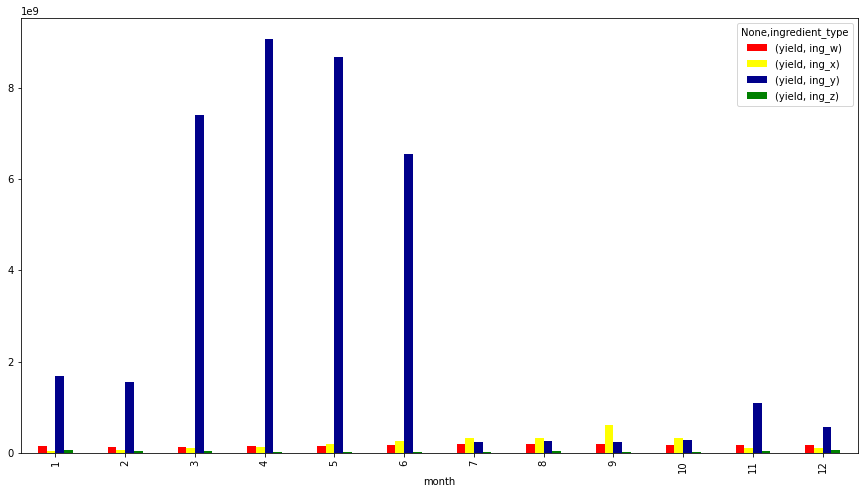

```python
#Each ingredient for each month yeild using bar plot
pd.DataFrame(final_train_merged.groupby(['month','ingredient_type'])['yield'].sum()).unstack().plot(kind = 'bar',figsize=(15,8),color =['red','yellow','darkblue','green'])
#we can see that for the 3,4,5,6 months has high yeild on ing_y compare to all months
```

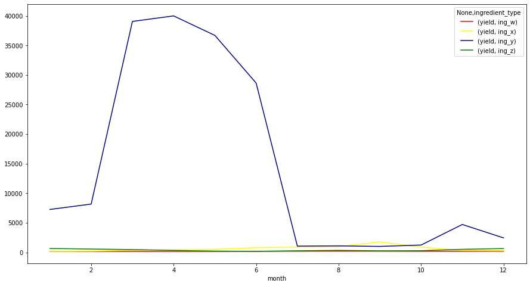

```python
#Each ingredient for each month yeild using line plot
pd.DataFrame(final_train_merged.groupby(['month','ingredient_type'])['yield'].mean()).unstack().plot(kind = 'line',figsize=(15,8),color =['red','yellow','darkblue','green'])
```

## Avg yeild for each company with all ingredient

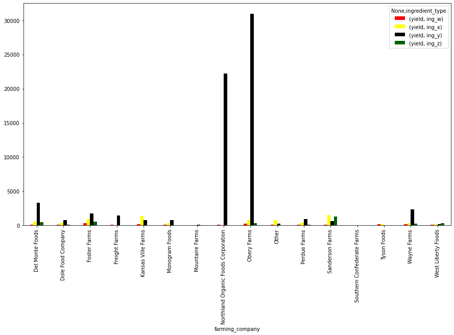

```python
##Average yeild for each ingredient and company using bar plot
pd.DataFrame(final_train_merged.groupby(['farming_company','ingredient_type'])['yield'].mean()).unstack().plot(kind = 'bar',figsize=(15,8),color =['red','yellow','black','darkgreen'])
# we see that two companys are producing high yeild of ing_y
```

## Average yeild for all ingredient in each location

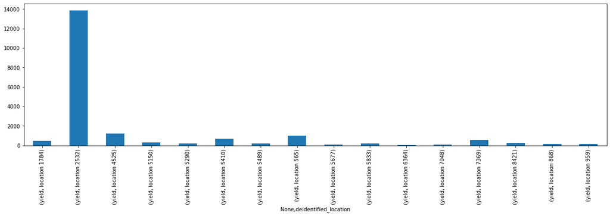

```python
#Mean of the yeild for each Location
pd.DataFrame(final_train_merged.groupby(['deidentified_location'])['yield'].mean()).unstack().plot(kind = 'bar',figsize=(20,5))
#Here avg yeild for 2nd Location is High
```

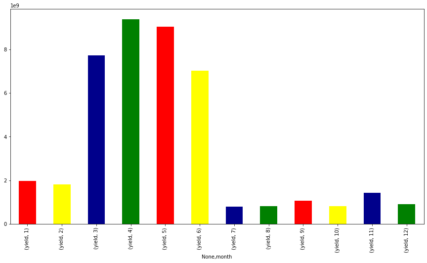

```python
#Total sum of yeild for each month
pd.DataFrame(final_train_merged.groupby(['month'])['yield'].sum()).unstack().plot(kind = 'bar',figsize=(15,8),color =['red','yellow','darkblue','green'])
```

## AVG yeild for each ingredient

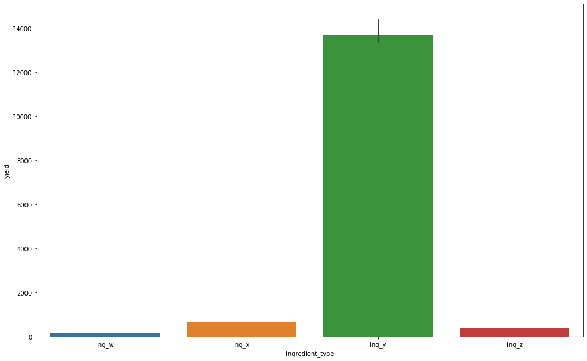

```python
#Averge yeild for each ingredient
#plt.figure(figsize = (16, 10))
#sns.barplot(y = "yield", x = "ingredient_type", data = final_train_merged)
#Ing_y is generating more yeild
#It is also taking more time 7mints
```

## AVG Farm area of each ingredient w.r.t Location

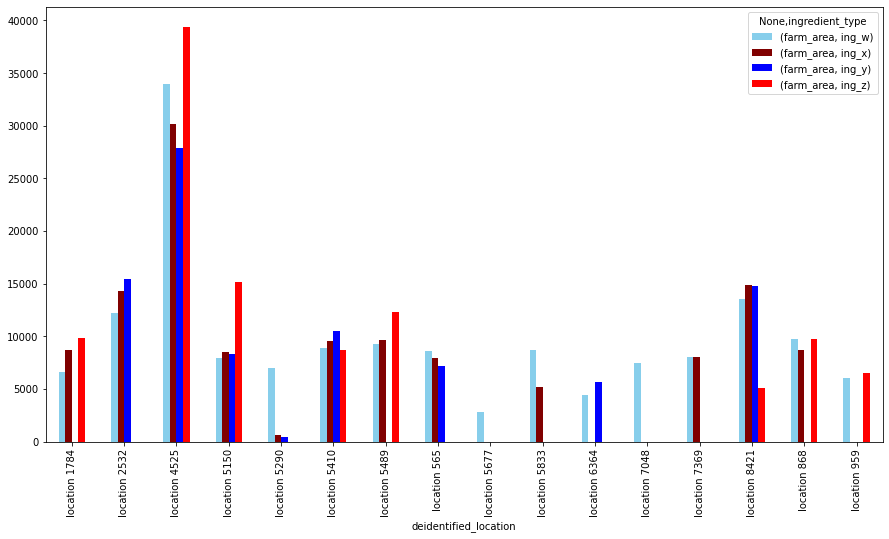

```python
pd.DataFrame(final_train_merged.groupby(['deidentified_location','ingredient_type'])['farm_area'].mean()).unstack().plot(kind = 'bar',figsize=(15,8),color =['skyblue','maroon','blue','red'])
```

```python
dd = pd.read_csv('linear_reg_predict.csv')
```

```python
dd.head()
```

|  | Unnamed: 0 | Prediction |
| --- | --- | --- |
| 0 | 0 | 2.333404e+06 |
| 1 | 1 | 2.323266e+06 |
| 2 | 2 | 2.318397e+06 |
| 3 | 3 | 2.319623e+06 |
| 4 | 4 | 2.322639e+06 |

```python
dd.shape
```

```
(20699880, 2)
```

## Temp_obs variation w.r.t each Location

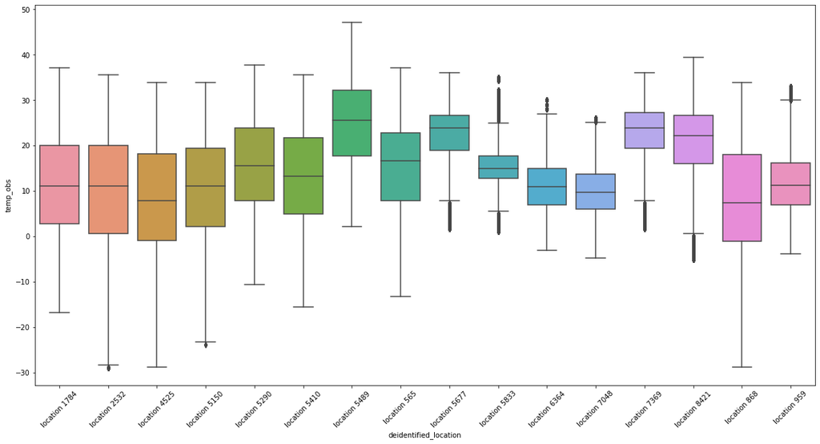

```python
#For each location how the temp_obs is distrubuted
plt.figure(figsize = (20, 10))

sns.boxplot(y = "temp_obs", x = "deidentified_location", data = final_train_merged)
plt.xticks(rotation = 45)
#For some locations we have outliers i.e the distrubution of the data for that particular month is diff from remaining months
```

```python
## Featuring Weekdays from Date column
final_train_merged['weekday_name'] =  pd.to_datetime(final_train_merged['date']).dt.day_name()
```

## sum of yeild for each day w.r.t whole year

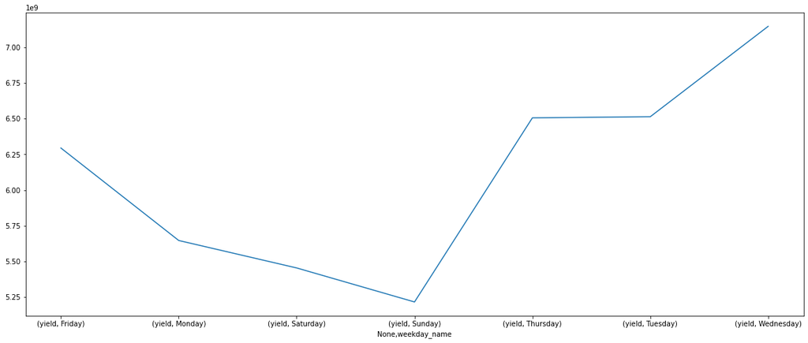

```python
#How the yeild is generating on the weekdays
pd.DataFrame(final_train_merged.groupby(['weekday_name'])['yield'].sum()).unstack().plot(kind = 'line',figsize=(20,8))
#we can see yeild for sunday and saturday is generating low yeild compareto remainging days
```

```python
#Extracting day of the year from the date which is in datetime format
final_train_merged['dayofyear'] = pd.to_datetime(final_train_merged['date']).dt.dayofyear
```

```python
#checking null values after final merge
final_train_merged.isnull().sum()
```

```
date                         0
farm_id                      0
ingredient_type              0
yield                        0
farm_area                    0
farming_company              0
deidentified_location        0
temp_obs                 89304
wind_direction           89304
dew_temp                 89304
pressure_sea_level       89304
precipitation            89304
wind_speed               89304
month                        0
weekday_name                 0
dayofyear                    0
dtype: int64
```

```python
#The col to impute after the merge
col_to_imputed_weather_again = ['temp_obs', 'wind_direction', 'dew_temp', 'pressure_sea_level','wind_speed','precipitation']
```

```python
#imputing with respetive locations on each day with there mean
final_train_merged[col_to_imputed_weather_again] = final_train_merged[col_to_imputed_weather_again].fillna(final_train_merged.groupby(['deidentified_location','dayofyear'])[col_to_imputed_weather_again].transform('mean'))
```

```python
# after imputation checking the Null values
final_train_merged.isnull().sum()
```

```
date                     0
farm_id                  0
ingredient_type          0
yield                    0
farm_area                0
farming_company          0
deidentified_location    0
temp_obs                 0
wind_direction           0
dew_temp                 0
pressure_sea_level       0
precipitation            0
wind_speed               0
month                    0
weekday_name             0
dayofyear                0
dtype: int64
```

```python
final_train_merged.describe()
```

|  | yield | farm_area | temp_obs | wind_direction | dew_temp | pressure_sea_level | precipitation | wind_speed | month | dayofyear |
| --- | --- | --- | --- | --- | --- | --- | --- | --- | --- | --- |
| count | 2.008053e+07 | 2.008053e+07 | 2.008053e+07 | 20080532.0 | 2.008053e+07 | 2.008053e+07 | 2.008053e+07 | 2.008053e+07 | 2.008053e+07 | 2.008053e+07 |
| mean | 2.054184e+03 | 9.528540e+03 | NaN | NaN | NaN | 1.016092e+03 | 8.793939e-01 | NaN | 6.577920e+00 | 1.854626e+02 |
| std | 1.537337e+05 | 1.059748e+04 | 0.000000e+00 | NaN | 0.000000e+00 | 6.902144e+00 | 7.131309e+00 | 0.000000e+00 | 3.436757e+00 | 1.052660e+02 |
| min | 0.000000e+00 | 2.629155e+01 | -2.890625e+01 | 0.0 | -3.500000e+01 | 9.680000e+02 | -1.000000e+00 | 0.000000e+00 | 1.000000e+00 | 1.000000e+00 |
| 25% | 1.840900e+01 | 3.021856e+03 | 8.500000e+00 | 80.0 | 0.000000e+00 | 1.012000e+03 | 0.000000e+00 | 2.099609e+00 | 4.000000e+00 | 9.600000e+01 |
| 50% | 7.921790e+01 | 6.719860e+03 | 1.670312e+01 | 170.0 | 8.898438e+00 | 1.016500e+03 | 0.000000e+00 | 3.099609e+00 | 7.000000e+00 | 1.860000e+02 |
| 75% | 2.688330e+02 | 1.291138e+04 | 2.400000e+01 | 270.0 | 1.609375e+01 | 1.020500e+03 | 0.000000e+00 | 4.601562e+00 | 1.000000e+01 | 2.760000e+02 |
| max | 2.190470e+07 | 8.129012e+04 | 4.718750e+01 | 360.0 | 2.609375e+01 | 1.046000e+03 | 3.430000e+02 | 1.900000e+01 | 1.200000e+01 | 3.660000e+02 |

## After preprossing spliting the data into Train and validation with 30%

```python
from sklearn.model_selection import train_test_split
```

```python
#Taking only required colms into X ,drop Target and dayofyear and date
x = final_train_merged.copy().drop(['yield','dayofyear','date'],axis=1)
```

```python
# Target attribute
y = final_train_merged['yield']
```

## Train test split

```python
#train_x and train_y contains 70% of the data
#validation_x and validation_y contains 30% of the data for testing the model
train_x, validation_x, train_y, validation_y = train_test_split(x,y,test_size= 0.30,random_state=124)
```

```python
print(train_x.shape)
print(train_y.shape)
print(validation_x.shape)
print(validation_y.shape)
```

```
(14056372, 13)
(14056372,)
(6024160, 13)
(6024160,)
```

```python
train_x.dtypes
#data types of the Train_x
```

```
farm_id                  category
ingredient_type          category
farm_area                 float32
farming_company          category
deidentified_location    category
temp_obs                  float16
wind_direction            float16
dew_temp                  float16
pressure_sea_level        float64
precipitation             float64
wind_speed                float16
month                       int64
weekday_name               object
dtype: object
```

```python
train_x.isnull().sum()
```

```
farm_id                  0
ingredient_type          0
farm_area                0
farming_company          0
deidentified_location    0
temp_obs                 0
wind_direction           0
dew_temp                 0
pressure_sea_level       0
precipitation            0
wind_speed               0
month                    0
weekday_name             0
dtype: int64
```

### Type convertion of the data types into category

```python
# colums to convert as category
cat_cols = ['farm_id', 'ingredient_type', 'farming_company','deidentified_location','month','weekday_name']
```

```python
#Type convertion into category
train_x[cat_cols] = train_x[cat_cols].astype("category")
```

```python
# same covertion to validation data
validation_x[cat_cols] =validation_x[cat_cols].astype("category")
```

```python
# importing lbys requried
from sklearn.preprocessing import StandardScaler, OneHotEncoder
```

```python
train_x.columns
```

```
Index(['farm_id', 'ingredient_type', 'farm_area', 'farming_company',
       'deidentified_location', 'temp_obs', 'wind_direction', 'dew_temp',
       'pressure_sea_level', 'precipitation', 'wind_speed', 'month',
       'weekday_name'],
      dtype='object')
```

```python
# colums to standardize
numeric_list=['farm_area','temp_obs','wind_direction','dew_temp','pressure_sea_level','precipitation','wind_speed']
```

```python
# i.e converting into Z score, range is -3 to +3 #formula (x-mue/sigma) ,mue = avr/mean,sigma= SD i.e Rootof (x-mue)square/n ,I.e n for Population
scaler = StandardScaler()
# Fit say's it understands the behavior of the X_train
scaler.fit(train_x[numeric_list])
#Transform will convert them into Z scores, for both train and valid
train_x[numeric_list] = scaler.transform(train_x[numeric_list])
validation_x[numeric_list] = scaler.transform(validation_x[numeric_list])
```

```python
# check whether it transoformed or not
train_x.head()
```

|  | farm_id | ingredient_type | farm_area | farming_company | deidentified_location | temp_obs | wind_direction | dew_temp | pressure_sea_level | precipitation | wind_speed | month | weekday_name |
| --- | --- | --- | --- | --- | --- | --- | --- | --- | --- | --- | --- | --- | --- |
| 14930897 | fid_71811 | ing_w | 0.185424 | Wayne Farms | location 2532 | -0.190621 | -0.096587 | -0.593605 | -0.085624 | -0.123312 | 1.471568 | 3 | Wednesday |
| 3214505 | fid_62549 | ing_w | -0.011342 | Dole Food Company | location 5489 | -0.035118 | 0.709937 | -1.251220 | -1.099578 | -0.123312 | 0.322110 | 3 | Wednesday |
| 19075958 | fid_96575 | ing_w | -0.219295 | Sanderson Farms | location 5150 | -0.035118 | 0.351482 | -0.102957 | -1.389279 | 0.073242 | 0.322110 | 5 | Saturday |
| 15744449 | fid_111372 | ing_w | 0.466759 | Wayne Farms | location 5410 | -1.203883 | 1.068393 | -1.359337 | -1.678980 | -0.123312 | 1.250319 | 11 | Monday |
| 3688141 | fid_53696 | ing_z | -0.171254 | Obery Farms | location 5489 | 0.877210 | 0.261868 | -1.801006 | -0.520176 | -0.123312 | -0.563750 | 3 | Thursday |

```python
train_x.dtypes
```

```
farm_id                  category
ingredient_type          category
farm_area                 float64
farming_company          category
deidentified_location    category
temp_obs                  float64
wind_direction            float64
dew_temp                  float64
pressure_sea_level        float64
precipitation             float64
wind_speed                float64
month                    category
weekday_name             category
dtype: object
```

```python
# convert Weekday_name into Category
train_x['weekday_name'] =train_x['weekday_name'].astype("category")
validation_x['weekday_name'] =validation_x['weekday_name'].astype("category")
```

```python
# convert month intlo category
train_x['month'] =train_x['month'].astype("category")
validation_x['month'] =validation_x['month'].astype("category")
```

### Columns to dummifie

##### We cant pass string or any objects directly to the model ,model cant understand the String type charater, to convert them into numeric we do dummification

```python
#colms to dummie
cols_to_dummi = ['ingredient_type', 'farming_company','deidentified_location','month','weekday_name']
```

```python
#creating dummie variables and drop_first = true for train data
train_x= pd.get_dummies(train_x,columns=cols_to_dummi,drop_first=True)
```

```python
#creating dummie variables and drop_first = true for validation data
validation_x= pd.get_dummies(validation_x,columns=cols_to_dummi,drop_first=True)
```

```python
# Drop farm_Id
train_x.drop("farm_id",axis =1,inplace =True)
validation_x.drop("farm_id",axis =1,inplace =True)
```

```python
train_x.sample(2)
```

|  | farm_area | temp_obs | wind_direction | dew_temp | pressure_sea_level | precipitation | wind_speed | ingredient_type_ing_x | ingredient_type_ing_y | ingredient_type_ing_z | ... | month_9 | month_10 | month_11 | month_12 | weekday_name_Monday | weekday_name_Saturday | weekday_name_Sunday | weekday_name_Thursday | weekday_name_Tuesday | weekday_name_Wednesday |
| --- | --- | --- | --- | --- | --- | --- | --- | --- | --- | --- | --- | --- | --- | --- | --- | --- | --- | --- | --- | --- | --- |
| 5538014 | -0.605216 | -1.203883 | 0.799551 | -1.310263 | -1.027153 | -0.123312 | 0.543359 | 0 | 0 | 0 | ... | 0 | 0 | 0 | 1 | 0 | 0 | 0 | 0 | 0 | 0 |
| 18538196 | -0.553997 | 0.922862 | 1.247620 | 1.144221 | -0.447750 | -0.123312 | 0.322110 | 0 | 0 | 0 | ... | 0 | 0 | 0 | 0 | 0 | 0 | 0 | 0 | 0 | 0 |

2 rows × 57 columns

# Model Building

```python
# Importing lyb required
from sklearn.linear_model import LinearRegression
from sklearn.metrics import mean_squared_error,mean_absolute_error
from sklearn import tree
from sklearn.model_selection import GridSearchCV
import math
```

```python
# Linear regression
reg = LinearRegression()
```

```python
#Fitting the train data with LRM model
reg.fit(train_x,train_y)
```

```
LinearRegression(copy_X=True, fit_intercept=True, n_jobs=None, normalize=False)
```

```python
reg.intercept_
```

```
27.252269973769216
```

```python
#Predition on Validation data
train_pred_lm=reg.predict(train_x)
test_pred_lm=reg.predict(validation_x)
```

```python
#R2 for train
print(reg.score(train_x,train_y))
```

```
0.0026781043920111047
```

```python
#definition of error metrics function for RMSE
from sklearn import metrics
import numpy as np
scores = pd.DataFrame(columns=['Model','RMSE_Train','RMSE_Test','R^2'])


#definition of error metrics function
def get_metrics(train_act,train_pred,test_act,test_pred,model_description,dataframe):
    RMSE_Train = np.sqrt(metrics.mean_squared_error(train_act,train_pred))
    RMSE_Test = np.sqrt(metrics.mean_squared_error(test_act,test_pred))
    R2=metrics.r2_score(train_act,train_pred)
    s1=pd.Series([model_description,RMSE_Train,RMSE_Test,R2],
                                           index=scores.columns)
    dataframe = dataframe.append(s1, ignore_index=True)
    return(dataframe)
```

```python
#scores for the Linear model
scores = get_metrics(train_y,reg.predict(train_x),validation_y,reg.predict(validation_x),"Linear_Regression",scores)
scores
```

|  | Model | RMSE_Train | RMSE_Test | R^2 |
| --- | --- | --- | --- | --- |
| 0 | Linear_Regression | 152986.410728 | 154836.097338 | 0.002678 |

## DecisionTree with Gridsearch

```python
from sklearn.metrics import mean_squared_error, mean_absolute_error, r2_score
from sklearn.tree import DecisionTreeRegressor, export_graphviz
from sklearn.model_selection import GridSearchCV
```

```python
#PrePrunig the data with max_depth,and aslo cross validation
#param_grid = {'max_depth': range(1, 11)}
#dt = DecisionTreeRegressor()
#clf = GridSearchCV(dt, param_grid, cv=10)
#clf.fit(train_x, train_y)
#Time taken to run the model is 2hr 22min
```

```
GridSearchCV(cv=10, error_score=nan,
             estimator=DecisionTreeRegressor(ccp_alpha=0.0, criterion='mse',
                                             max_depth=None, max_features=None,
                                             max_leaf_nodes=None,
                                             min_impurity_decrease=0.0,
                                             min_impurity_split=None,
                                             min_samples_leaf=1,
                                             min_samples_split=2,
                                             min_weight_fraction_leaf=0.0,
                                             presort='deprecated',
                                             random_state=None,
                                             splitter='best'),
             iid='deprecated', n_jobs=None,
             param_grid={'max_depth': range(1, 11)}, pre_dispatch='2*n_jobs',
             refit=True, return_train_score=False, scoring=None, verbose=0)
```

```python
print(clf.best_params_)
```

```
{'max_depth': 10}
```

```python
#Prediting for train and validation
train_pred = clf.predict(train_x)
test_pred = clf.predict(validation_x)
```

```python
#r2 for the Decision tree
print(clf.score(train_x,train_y))
print(clf.score(validation_x,validation_y))
```

```
0.8832248591064741
0.8474841579920417
```

```python
#Scores for the Decsion tree
scores = get_metrics(train_y,clf.predict(train_x),validation_y,clf.predict(validation_x),"DecisionTree with pramgrid",scores)
scores
```

|  | Model | RMSE_Train | RMSE_Test | R^2 |
| --- | --- | --- | --- | --- |
| 0 | Linear_Regression | 152986.410728 | 154836.097338 | 0.002678 |
| 1 | DecisionTree with pramgrid | 52349.239716 | 60552.607603 | 0.883225 |

**The decision Tree model is built by using the train data and had the predictions but the performance is not satisfactory for better performance I thought of using Ensembles one of the methods is random-forest While using the random-forest kernel got crashed every time because of optimization.**

[figure not shown]

```python
# Build models ensemble crashed of optimization
Image('Kernal crash img.png',height=700 , width=950)
```

# Test data

## Test data preprossing

#### Same steps what we have done in train same for the test data

```python
test_data
```

|  | date | farm_id | ingredient_type | id |
| --- | --- | --- | --- | --- |
| 0 | 2017-01-01 00:00:00 | fid_110884 | ing_w | 0 |
| 1 | 2017-01-01 00:00:00 | fid_90053 | ing_w | 1 |
| 2 | 2017-01-01 00:00:00 | fid_17537 | ing_w | 2 |
| 3 | 2017-01-01 00:00:00 | fid_110392 | ing_w | 3 |
| 4 | 2017-01-01 00:00:00 | fid_62402 | ing_w | 4 |
| ... | ... | ... | ... | ... |
| 20848795 | 2017-12-25 07:00:00 | fid_58769 | ing_x | 41696845 |
| 20848796 | 2017-12-25 07:00:00 | fid_58769 | ing_z | 41696846 |
| 20848797 | 2017-12-25 07:00:00 | fid_117010 | ing_w | 41696847 |
| 20848798 | 2017-12-25 07:00:00 | fid_117010 | ing_x | 41696848 |
| 20848799 | 2017-12-25 07:00:00 | fid_117010 | ing_z | 41696849 |

20848800 rows × 4 columns

```python
test_data.groupby('farm_id')['ingredient_type'].nunique().reset_index(name='counts')
```

|  | farm_id | counts |
| --- | --- | --- |
| 0 | fid_100053 | 1 |
| 1 | fid_100107 | 3 |
| 2 | fid_100135 | 1 |
| 3 | fid_100249 | 1 |
| 4 | fid_100303 | 1 |
| ... | ... | ... |
| 1429 | fid_99437 | 1 |
| 1430 | fid_99482 | 1 |
| 1431 | fid_99826 | 1 |
| 1432 | fid_99921 | 2 |
| 1433 | fid_99942 | 3 |

1434 rows × 2 columns

```python
print('test_weather')
test_weather = import_data('test_weather-1646897984996-1664552604982.csv')
```

```
test_weather
Memory usage of dataframe is 9.53 MB
Memory usage after optimization is: 2.63 MB
Decreased by 72.4%
```

```python
duplicateRowsDF = test_weather[test_weather.duplicated()]

print("Duplicate Rows except first occurrence based on all columns are :")
print(len(duplicateRowsDF))
```

```
Duplicate Rows except first occurrence based on all columns are :
0
```

```python
duplicateRowsDF = test_weather[test_weather[['timestamp','deidentified_location']].duplicated()]

print("Duplicate Rows except first occurrence based on all columns are :")
print(len(duplicateRowsDF))
```

```
Duplicate Rows except first occurrence based on all columns are :
0
```

```python
duplicateRowsDF = test_data[test_data.duplicated()]

print("Duplicate Rows except first occurrence based on all columns are :")
print(len(duplicateRowsDF))
```

```
Duplicate Rows except first occurrence based on all columns are :
0
```

```python
test_data2 = test_data.drop("id", axis=1)
```

```python
duplicateRowsDF = test_data2[test_data2.duplicated()]

print("Duplicate Rows except first occurrence based on all columns are :")
print(len(duplicateRowsDF))
```

```
Duplicate Rows except first occurrence based on all columns are :
148920
```

```python
test_data2
```

|  | date | farm_id | ingredient_type |
| --- | --- | --- | --- |
| 0 | 2017-01-01 00:00:00 | fid_110884 | ing_w |
| 1 | 2017-01-01 00:00:00 | fid_90053 | ing_w |
| 2 | 2017-01-01 00:00:00 | fid_17537 | ing_w |
| 3 | 2017-01-01 00:00:00 | fid_110392 | ing_w |
| 4 | 2017-01-01 00:00:00 | fid_62402 | ing_w |
| ... | ... | ... | ... |
| 20848795 | 2017-12-25 07:00:00 | fid_58769 | ing_x |
| 20848796 | 2017-12-25 07:00:00 | fid_58769 | ing_z |
| 20848797 | 2017-12-25 07:00:00 | fid_117010 | ing_w |
| 20848798 | 2017-12-25 07:00:00 | fid_117010 | ing_x |
| 20848799 | 2017-12-25 07:00:00 | fid_117010 | ing_z |

20848800 rows × 3 columns

```python
missing(test_data2)
```

```
date               0.0
farm_id            0.0
ingredient_type    0.0
dtype: float64
```

```python
missing(test_weather)
```

```
timestamp                 0.000000
deidentified_location     0.000000
temp_obs                  0.030974
cloudiness               49.749685
wind_direction            4.418513
dew_temp                  0.132541
pressure_sea_level        7.839366
precipitation            34.423195
wind_speed                0.172880
dtype: float64
```

```python
# droping >40% variables
min_threshold_na_weather_test = test_weather.shape[0]*0.60
test_weather.dropna( thresh=min_threshold_na_weather_test, axis=1,inplace=True)
```

```python
test_weather.columns
```

```
Index(['timestamp', 'deidentified_location', 'temp_obs', 'wind_direction',
       'dew_temp', 'pressure_sea_level', 'precipitation', 'wind_speed'],
      dtype='object')
```

```python
test_weather['precipitation'].value_counts()
```

```
 0.0      78640
-1.0       5964
 3.0       1612
 5.0        852
 2.0        530
          ...
 442.0        1
 99.0         1
 201.0        1
 140.0        1
 150.0        1
Name: precipitation, Length: 144, dtype: int64
```

```python
test_weather['timestamp'] = pd.to_datetime(test_weather['timestamp'])
test_weather['dayofyear'] = test_weather['timestamp'].dt.dayofyear
```

```python
test_weather[col_to_imputed_weather] = test_weather[col_to_imputed_weather].fillna(test_weather.groupby(['deidentified_location','dayofyear'])[col_to_imputed_weather].transform('mean'))
```

```python
test_weather.isnull().sum()
```

```
timestamp                    0
deidentified_location        0
temp_obs                     0
wind_direction               0
dew_temp                     0
pressure_sea_level        9037
precipitation            38238
wind_speed                   0
dayofyear                    0
dtype: int64
```

```python
test_weather.pressure_sea_level.value_counts().sort_values()
```

```
976.5        1
972.0        1
1050.0       2
973.5        2
975.5        2
          ...
1014.5    3945
1015.5    3961
1016.5    3986
1015.0    3996
1016.0    4034
Name: pressure_sea_level, Length: 130, dtype: int64
```

```python
from sklearn.impute import SimpleImputer
null_cols=['pressure_sea_level',"precipitation"]
imputer = SimpleImputer(strategy='median', missing_values=np.nan)
```

```python
imputer = imputer.fit(test_weather[null_cols])
test_weather[null_cols]= imputer.transform(test_weather[null_cols])
```

```python
test_weather.drop("dayofyear",axis =1,inplace =True)
```

```python
initial_merged_test = pd.merge(test_data2, farm_data2,on = "farm_id")
```

```python
duplicateRowsDF = initial_merged_test[initial_merged_test.duplicated()]

print("Duplicate Rows except first occurrence based on all columns are :")
print(len(duplicateRowsDF))
```

```
Duplicate Rows except first occurrence based on all columns are :
148920
```

[figure not shown]

```python
# Droping duplicates and getting predictions, when submitting CSV file got and input shape error
# For the sake of submission I did not droped the duplicates
Image('Input shape error without duplicates.png',height=500 , width=650)
```

```python
initial_merged_test.groupby('deidentified_location')['date'].nunique().reset_index(name='counts')
```

|  | deidentified_location | counts |
| --- | --- | --- |
| 0 | location 1784 | 8760 |
| 1 | location 2532 | 8760 |
| 2 | location 4525 | 8760 |
| 3 | location 5150 | 8760 |
| 4 | location 5290 | 8760 |
| 5 | location 5410 | 8760 |
| 6 | location 5489 | 8760 |
| 7 | location 565 | 8760 |
| 8 | location 5677 | 8760 |
| 9 | location 5833 | 8760 |
| 10 | location 6364 | 8760 |
| 11 | location 7048 | 8760 |
| 12 | location 7369 | 8760 |
| 13 | location 8421 | 8760 |
| 14 | location 868 | 8760 |
| 15 | location 959 | 8760 |

```python
initial_merged_test.dtypes
```

```
date                     datetime64[ns]
farm_id                        category
ingredient_type                category
farm_area                       float32
farming_company                category
deidentified_location          category
dtype: object
```

```python
initial_merged_test.shape
```

```
(20848800, 6)
```

```python
initial_merged_test.isnull().sum()
```

```
date                     0
farm_id                  0
ingredient_type          0
farm_area                0
farming_company          0
deidentified_location    0
dtype: int64
```

```python
test_weather.rename(columns = {'timestamp':'date'}, inplace = True)
```

```python
test_weather['date'] = test_weather['date'].astype("object")
initial_merged_test['date'] = initial_merged_test['date'].astype("object")
```

```python
test_weather['date'] = pd.to_datetime(test_weather['date'])
initial_merged_test['date'] = pd.to_datetime(initial_merged_test['date'])
```

```python
final_test_merged=pd.merge(initial_merged_test,test_weather,how="left",left_on=["deidentified_location","date"],right_on=['deidentified_location','date'])
```

```python
final_test_merged['date'] = final_test_merged['date'].astype("object")
```

```python
final_test_merged['date'] = pd.to_datetime(final_test_merged['date'])
```

```python
final_test_merged.dtypes
```

```
date                     datetime64[ns]
farm_id                        category
ingredient_type                category
farm_area                       float32
farming_company                category
deidentified_location          category
temp_obs                        float16
wind_direction                  float16
dew_temp                        float16
pressure_sea_level              float64
precipitation                   float64
wind_speed                      float16
dtype: object
```

```python
final_test_merged.isnull().sum()
```

```
date                         0
farm_id                      0
ingredient_type              0
farm_area                    0
farming_company              0
deidentified_location        0
temp_obs                 95416
wind_direction           95416
dew_temp                 95416
pressure_sea_level       95416
precipitation            95416
wind_speed               95416
dtype: int64
```

```python
final_test_merged.columns
```

```
Index(['date', 'farm_id', 'ingredient_type', 'farm_area', 'farming_company',
       'deidentified_location', 'temp_obs', 'wind_direction', 'dew_temp',
       'pressure_sea_level', 'precipitation', 'wind_speed'],
      dtype='object')
```

```python
final_test_merged['dayofyear'] = final_test_merged['date'].dt.dayofyear
```

```python
final_test_merged[col_to_imputed_weather_again] = final_test_merged[col_to_imputed_weather_again].fillna(final_test_merged.groupby(['deidentified_location','dayofyear'])[col_to_imputed_weather_again].transform('mean'))
```

```python
final_test_merged.isnull().sum()
```

```
date                         0
farm_id                      0
ingredient_type              0
farm_area                    0
farming_company              0
deidentified_location        0
temp_obs                 14784
wind_direction           14784
dew_temp                 14784
pressure_sea_level       14784
precipitation            14784
wind_speed               14784
dayofyear                    0
dtype: int64
```

```python
final_test_merged[col_to_imputed_weather_again] = final_test_merged[col_to_imputed_weather_again].fillna(final_test_merged.groupby('deidentified_location')[col_to_imputed_weather_again].transform('mean'))
```

```python
final_test_merged.isnull().sum()
```

```
date                     0
farm_id                  0
ingredient_type          0
farm_area                0
farming_company          0
deidentified_location    0
temp_obs                 0
wind_direction           0
dew_temp                 0
pressure_sea_level       0
precipitation            0
wind_speed               0
dayofyear                0
dtype: int64
```

```python
final_test_merged['weekday_name'] =  pd.to_datetime(final_test_merged['date']).dt.day_name()
```

```python
final_test_merged['month'] = pd.to_datetime(final_test_merged['date']).dt.month
```

```python
final_test_merged.drop(['dayofyear','date','farm_id'],axis=1,inplace=True)
```

```python
final_test_merged
```

|  | ingredient_type | farm_area | farming_company | deidentified_location | temp_obs | wind_direction | dew_temp | pressure_sea_level | precipitation | wind_speed | weekday_name | month |
| --- | --- | --- | --- | --- | --- | --- | --- | --- | --- | --- | --- | --- |
| 0 | ing_w | 690.455078 | Obery Farms | location 7369 | 17.796875 | 100.0 | 11.703125 | 1021.5000 | 0.0 | 3.599609 | Sunday | 1 |
| 1 | ing_w | 690.455078 | Obery Farms | location 7369 | 17.796875 | 130.0 | 12.796875 | 1022.0000 | 0.0 | 3.099609 | Sunday | 1 |
| 2 | ing_w | 690.455078 | Obery Farms | location 7369 | 16.093750 | 140.0 | 12.796875 | 1022.0000 | 0.0 | 3.099609 | Sunday | 1 |
| 3 | ing_w | 690.455078 | Obery Farms | location 7369 | 17.203125 | 140.0 | 13.296875 | 1022.0000 | 0.0 | 3.099609 | Sunday | 1 |
| 4 | ing_w | 690.455078 | Obery Farms | location 7369 | 16.703125 | 130.0 | 13.296875 | 1022.5000 | 0.0 | 2.599609 | Sunday | 1 |
| ... | ... | ... | ... | ... | ... | ... | ... | ... | ... | ... | ... | ... |
| 20848795 | ing_w | 8572.252930 | Wayne Farms | location 5150 | -14.328125 | 308.0 | -18.156250 | 1035.0625 | -1.0 | 6.230469 | Thursday | 12 |
| 20848796 | ing_w | 8572.252930 | Wayne Farms | location 5150 | -14.328125 | 308.0 | -18.156250 | 1035.0625 | -1.0 | 6.230469 | Thursday | 12 |
| 20848797 | ing_w | 8572.252930 | Wayne Farms | location 5150 | -14.328125 | 308.0 | -18.156250 | 1035.0625 | -1.0 | 6.230469 | Thursday | 12 |
| 20848798 | ing_w | 8572.252930 | Wayne Farms | location 5150 | -14.328125 | 308.0 | -18.156250 | 1035.0625 | -1.0 | 6.230469 | Thursday | 12 |
| 20848799 | ing_w | 8572.252930 | Wayne Farms | location 5150 | -14.328125 | 308.0 | -18.156250 | 1035.0625 | -1.0 | 6.230469 | Thursday | 12 |

20848800 rows × 12 columns

# final_test_merged

```python
cat_cols = [ 'ingredient_type', 'farming_company','deidentified_location','month','weekday_name']
```

```python
final_test_merged[cat_cols] = final_test_merged[cat_cols].astype("category")
```

```python
final_test_merged.dtypes
```

```
ingredient_type          category
farm_area                 float32
farming_company          category
deidentified_location    category
temp_obs                  float16
wind_direction            float16
dew_temp                  float16
pressure_sea_level        float64
precipitation             float64
wind_speed                float16
weekday_name             category
month                    category
dtype: object
```

```python
numeric_list=['farm_area','temp_obs','wind_direction','dew_temp','pressure_sea_level','precipitation','wind_speed']
```

```python
scaler = StandardScaler()
scaler.fit(train_x[numeric_list])
final_test_merged[numeric_list] = scaler.transform(final_test_merged[numeric_list])
```

```python
cols_to_dummi = ['ingredient_type', 'farming_company','deidentified_location','month','weekday_name']
```

```python
final_test_merged= pd.get_dummies(final_test_merged,columns=cols_to_dummi,drop_first=True)
```

```python
final_test_merged
```

|  | farm_area | temp_obs | wind_direction | dew_temp | pressure_sea_level | precipitation | wind_speed | ingredient_type_ing_x | ingredient_type_ing_y | ingredient_type_ing_z | ... | month_9 | month_10 | month_11 | month_12 | weekday_name_Monday | weekday_name_Saturday | weekday_name_Sunday | weekday_name_Thursday | weekday_name_Tuesday | weekday_name_Wednesday |
| --- | --- | --- | --- | --- | --- | --- | --- | --- | --- | --- | --- | --- | --- | --- | --- | --- | --- | --- | --- | --- | --- |
| 0 | 690.455078 | 17.796875 | 100.0 | 11.703125 | 1021.5000 | -3.549334e-17 | 3.599609 | 0 | 0 | 0 | ... | 0 | 0 | 0 | 0 | 0 | 0 | 1 | 0 | 0 | 0 |
| 1 | 690.455078 | 17.796875 | 130.0 | 12.796875 | 1022.0000 | -3.549334e-17 | 3.099609 | 0 | 0 | 0 | ... | 0 | 0 | 0 | 0 | 0 | 0 | 1 | 0 | 0 | 0 |
| 2 | 690.455078 | 16.093750 | 140.0 | 12.796875 | 1022.0000 | -3.549334e-17 | 3.099609 | 0 | 0 | 0 | ... | 0 | 0 | 0 | 0 | 0 | 0 | 1 | 0 | 0 | 0 |
| 3 | 690.455078 | 17.203125 | 140.0 | 13.296875 | 1022.0000 | -3.549334e-17 | 3.099609 | 0 | 0 | 0 | ... | 0 | 0 | 0 | 0 | 0 | 0 | 1 | 0 | 0 | 0 |
| 4 | 690.455078 | 16.703125 | 130.0 | 13.296875 | 1022.5000 | -3.549334e-17 | 2.599609 | 0 | 0 | 0 | ... | 0 | 0 | 0 | 0 | 0 | 0 | 1 | 0 | 0 | 0 |
| ... | ... | ... | ... | ... | ... | ... | ... | ... | ... | ... | ... | ... | ... | ... | ... | ... | ... | ... | ... | ... | ... |
| 20848795 | 8572.252930 | -14.328125 | 308.0 | -18.156250 | 1035.0625 | -1.000000e+00 | 6.230469 | 0 | 0 | 0 | ... | 0 | 0 | 0 | 1 | 0 | 0 | 0 | 1 | 0 | 0 |
| 20848796 | 8572.252930 | -14.328125 | 308.0 | -18.156250 | 1035.0625 | -1.000000e+00 | 6.230469 | 0 | 0 | 0 | ... | 0 | 0 | 0 | 1 | 0 | 0 | 0 | 1 | 0 | 0 |
| 20848797 | 8572.252930 | -14.328125 | 308.0 | -18.156250 | 1035.0625 | -1.000000e+00 | 6.230469 | 0 | 0 | 0 | ... | 0 | 0 | 0 | 1 | 0 | 0 | 0 | 1 | 0 | 0 |
| 20848798 | 8572.252930 | -14.328125 | 308.0 | -18.156250 | 1035.0625 | -1.000000e+00 | 6.230469 | 0 | 0 | 0 | ... | 0 | 0 | 0 | 1 | 0 | 0 | 0 | 1 | 0 | 0 |
| 20848799 | 8572.252930 | -14.328125 | 308.0 | -18.156250 | 1035.0625 | -1.000000e+00 | 6.230469 | 0 | 0 | 0 | ... | 0 | 0 | 0 | 1 | 0 | 0 | 0 | 1 | 0 | 0 |

20848800 rows × 57 columns

```python
org_test_pred_lm=reg.predict(final_test_merged)
```

```python
#It took 1mint to predict for the test data
org_test_pred_DT_Withparamgrid = clf.predict(final_test_merged)
```

# converting prediction to data frame

```python
#Converting predition into dataframe and that convert to csv file
#pd.DataFrame({"Prediction":org_test_pred_lm}).to_csv("linear_reg_predict.csv")
```

```python
#Converting predition into dataframe and that convert to csv file
pd.DataFrame({"Prediction":org_test_pred_DT_Withparamgrid}).to_csv("DT_withparamgrid_predict_withduplicate.csv")
```

```python
dd= pd.read_csv("linear_reg_predict.csv")
print(dd.shape)
```

```
(20848800, 2)
```

```python
#train_x['weekday'] = train_x['date'].dt.weekday
#train_x['day_name'] = train_x['date'].dt.weekday_name
#train_x['dayofyear'] = train_x['date'].dt.dayofyear
#trainx['weekofyear'] = trainx['date'].dt.weekofyear
#train_x['day'] = train_x['date'].dt.day
#train_x['month'] = train_x['date'].dt.month
#train_x['quarter'] = train_x['date'].dt.quarter
#train_x['is_month_end'] = train_x['date'].dt.is_month_end
#train_x['is_month_start'] = train_x['date'].dt.is_month_start
# trainx['is_quarter_end'] = train_x['date'].dt.is_quarter_end
# trainx['is_quarter_start'] = trainx['date'].dt.is_quarter_start
#train_x['hour'] = train_x['date'].dt.hour
```

**The decision Tree model is built by using the train data and had the predictions but the performance is not satisfactory for better performance I thought of using Ensembles one of the methods is random-forest While using the random-forest kernel got crashed every time because of optimization, to address this problem I thought of considering a subset to represent the whole data and built a model on it.**

```python
# Importing Library's requried
# Read the data files of subset data
# Performing steps like shape,missing values count,and describe function for the datasets
# Drop the yeild and checked for the duplicates and that duplicates are taken avg of there yeild rather droping duplicate records
# And concat them with the orignal data
# Drop duplicates in farm data and weather data
# Drop the attributes which are >40%
# Imputation for the weather data w.r.t location for each day and impute the avg of each day temprature for the missing values
# Merged 3 datasets and checked for missing values and again imputed with respeted location and day of the year
#
# visualization part

# Train-valid split
# Type convertion, Standardization , creating Dummies for catergorical attributes

# Model Buliding for the train data and evaluate the error metric for the validation data
# Get predictions and scores

# Test Preprocessing
# All train operation is done for the testdata but there are duplicates in the test data
# and if i drop the records the prediction file shape and smaple submission file shape will not be same when subbmitting the predictions. I faced an issue with that
```

# Subset Data of Last 4Months data

```python
import pandas as pd
import numpy as np
import matplotlib.pyplot as plt
import seaborn as sns
%matplotlib inline
import warnings
from IPython.display import Image
warnings.filterwarnings('ignore')
import os
import sklearn
```

```python
def reduce_mem_usage(df):
    """ iterate through all the columns of a dataframe and modify the data type
        to reduce memory usage.
    """
    start_mem = df.memory_usage().sum() / 1024**2
    print('Memory usage of dataframe is {:.2f} MB'.format(start_mem))

    for col in df.columns:
        col_type = df[col].dtype

        if col_type != object:
            c_min = df[col].min()
            c_max = df[col].max()
            if str(col_type)[:3] == 'int':
                if c_min > np.iinfo(np.int8).min and c_max < np.iinfo(np.int8).max:
                    df[col] = df[col].astype(np.int8)
                elif c_min > np.iinfo(np.int16).min and c_max < np.iinfo(np.int16).max:
                    df[col] = df[col].astype(np.int16)
                elif c_min > np.iinfo(np.int32).min and c_max < np.iinfo(np.int32).max:
                    df[col] = df[col].astype(np.int32)
                elif c_min > np.iinfo(np.int64).min and c_max < np.iinfo(np.int64).max:
                    df[col] = df[col].astype(np.int64)
            else:
                if c_min > np.finfo(np.float16).min and c_max < np.finfo(np.float16).max:
                    df[col] = df[col].astype(np.float16)
                elif c_min > np.finfo(np.float32).min and c_max < np.finfo(np.float32).max:
                    df[col] = df[col].astype(np.float32)
                else:
                    df[col] = df[col].astype(np.float64)
        else:
            df[col] = df[col].astype('category')

    end_mem = df.memory_usage().sum() / 1024**2
    print('Memory usage after optimization is: {:.2f} MB'.format(end_mem))
    print('Decreased by {:.1f}%'.format(100 * (start_mem - end_mem) / start_mem))

    return df


def import_data(file):
    """create a dataframe and optimize its memory usage"""
    df = pd.read_csv(file, parse_dates=True, keep_date_col=True)
    df = reduce_mem_usage(df)
    return df
```

```python
print('-' * 80)
print('train_data')
train_data = import_data('train_data.csv')

print('-' * 80)
print('farm_data')
farm_data = import_data("farm_data-1646897931981.csv")

print('-' * 80)
print('train_weather')
train_weather = import_data('train_weather-1646897968670.csv')

print('-' * 80)
print('test_data')
test_data = import_data('test_data-1664552867678.csv')

print('-' * 80)
print('test_weather')
test_weather = import_data('test_weather-1646897984996-1664552604982.csv')
```

```
--------------------------------------------------------------------------------
train_data
Memory usage of dataframe is 616.95 MB
Memory usage after optimization is: 173.95 MB
Decreased by 71.8%
--------------------------------------------------------------------------------
farm_data
Memory usage of dataframe is 0.07 MB
Memory usage after optimization is: 0.07 MB
Decreased by -2.6%
--------------------------------------------------------------------------------
train_weather
Memory usage of dataframe is 9.60 MB
Memory usage after optimization is: 2.65 MB
Decreased by 72.4%
--------------------------------------------------------------------------------
test_data
Memory usage of dataframe is 636.26 MB
Memory usage after optimization is: 179.38 MB
Decreased by 71.8%
--------------------------------------------------------------------------------
test_weather
Memory usage of dataframe is 9.53 MB
Memory usage after optimization is: 2.63 MB
Decreased by 72.4%
```

```python
#Using loc function
print(train_data[train_data['date']== '2017-09-01 00:00:00'].index.values)
```

```
[]
```

```python
train = train_data.loc[13358457:20216099]
```

```python
train.head()
```

|  | date | farm_id | ingredient_type | yield |
| --- | --- | --- | --- | --- |
| 13358457 | 2016-09-01 00:00:00 | fid_110884 | ing_w | 255.960007 |
| 13358458 | 2016-09-01 00:00:00 | fid_90053 | ing_w | 141.153000 |
| 13358459 | 2016-09-01 00:00:00 | fid_17537 | ing_w | 17.610100 |
| 13358460 | 2016-09-01 00:00:00 | fid_110392 | ing_w | 420.115997 |
| 13358461 | 2016-09-01 00:00:00 | fid_62402 | ing_w | 1577.400024 |

```python
print(train.shape)
```

```
(6857643, 4)
```

```python
train['date'] = train['date'].astype("object")
```

```python
train['date'] = pd.to_datetime(train['date'])
```

```python
train.groupby('farm_id')['date'].nunique().reset_index(name='counts').sort_values(by = ['counts'])
```

|  | farm_id | counts |
| --- | --- | --- |
| 996 | fid_63398 | 0 |
| 247 | fid_118770 | 0 |
| 1116 | fid_73322 | 149 |
| 265 | fid_120541 | 264 |
| 405 | fid_19864 | 479 |
| ... | ... | ... |
| 623 | fid_36336 | 2928 |
| 624 | fid_36342 | 2928 |
| 628 | fid_36575 | 2928 |
| 600 | fid_34570 | 2928 |
| 1433 | fid_99942 | 2928 |

1434 rows × 2 columns

```python
train.groupby('farm_id')['ingredient_type'].nunique().reset_index(name='counts')
```

|  | farm_id | counts |
| --- | --- | --- |
| 0 | fid_100053 | 1 |
| 1 | fid_100107 | 3 |
| 2 | fid_100135 | 1 |
| 3 | fid_100249 | 1 |
| 4 | fid_100303 | 1 |
| ... | ... | ... |
| 1429 | fid_99437 | 1 |
| 1430 | fid_99482 | 1 |
| 1431 | fid_99826 | 1 |
| 1432 | fid_99921 | 2 |
| 1433 | fid_99942 | 3 |

1434 rows × 2 columns

```python
len(train.loc[train['yield']==0,:])
```

```
527057
```

```python
len(train.loc[train['yield']>=1000,:])
```

```
562432
```

```python
train.describe()
```

|  | yield |
| --- | --- |
| count | 6.857643e+06 |
| mean | 6.114519e+02 |
| std | 4.267146e+04 |
| min | 0.000000e+00 |
| 25% | 1.982000e+01 |
| 50% | 8.200000e+01 |
| 75% | 2.766350e+02 |
| max | 2.184790e+07 |

```python
duplicateRowsDF = train[train.duplicated()]

print("Duplicate Rows :")
print(len(duplicateRowsDF))
```

```
Duplicate Rows :
109
```

```python
train2 = train.drop("yield", axis=1)
```

```python
duplicateRowsDF = train2[train2.duplicated()]

print("Duplicate Rows except first occurrence based on all columns are :")
print(len(duplicateRowsDF))
```

```
Duplicate Rows except first occurrence based on all columns are :
47350
```

```python
train.drop_duplicates(inplace=True)
```

```python
train.shape
```

```
(6857534, 4)
```

```python
train.columns
```

```
Index(['date', 'farm_id', 'ingredient_type', 'yield'], dtype='object')
```

```python
train.duplicated(subset=['date', 'farm_id', 'ingredient_type']).sum()
```

```
47241
```

```python
train.loc[train.duplicated(subset=['date', 'farm_id', 'ingredient_type'],keep=False),:].sort_values(by = ['date','farm_id','ingredient_type'])
```

|  | date | farm_id | ingredient_type | yield |
| --- | --- | --- | --- | --- |
| 13359987 | 2016-09-01 00:00:00 | fid_122174 | ing_w | 123.556000 |
| 13360103 | 2016-09-01 00:00:00 | fid_122174 | ing_w | 37.569000 |
| 13359179 | 2016-09-01 00:00:00 | fid_18990 | ing_w | 124.209999 |
| 13359235 | 2016-09-01 00:00:00 | fid_18990 | ing_w | 345.757996 |
| 13359152 | 2016-09-01 00:00:00 | fid_26064 | ing_w | 4.240000 |
| ... | ... | ... | ... | ... |
| 20215484 | 2016-12-31 23:00:00 | fid_73431 | ing_w | 107.867996 |
| 20214247 | 2016-12-31 23:00:00 | fid_81333 | ing_w | 42.320000 |
| 20214568 | 2016-12-31 23:00:00 | fid_81333 | ing_w | 391.625000 |
| 20214316 | 2016-12-31 23:00:00 | fid_97094 | ing_w | 15.140000 |
| 20215920 | 2016-12-31 23:00:00 | fid_97094 | ing_w | 2.400000 |

94482 rows × 4 columns

```python
dropped_dup_train4m = train.loc[train.duplicated(subset=['date', 'farm_id', 'ingredient_type'],keep=False),:].sort_values(by = ['date','farm_id','ingredient_type'])
```

```python
dropped_dup_train4m.shape
```

```
(94482, 4)
```

```python
dropped_dup_train4m.head()
```

|  | date | farm_id | ingredient_type | yield |
| --- | --- | --- | --- | --- |
| 13359987 | 2016-09-01 | fid_122174 | ing_w | 123.556000 |
| 13360103 | 2016-09-01 | fid_122174 | ing_w | 37.569000 |
| 13359179 | 2016-09-01 | fid_18990 | ing_w | 124.209999 |
| 13359235 | 2016-09-01 | fid_18990 | ing_w | 345.757996 |
| 13359152 | 2016-09-01 | fid_26064 | ing_w | 4.240000 |

```python
train2_2 = train.copy()
```

```python
train2_2.drop_duplicates(subset=['date', 'farm_id', 'ingredient_type'],keep=False).shape
```

```
(6763052, 4)
```

```python
train2_2.drop_duplicates(subset=['date', 'farm_id', 'ingredient_type'],keep=False,inplace=True)
```

```python
train2_2.shape
```

```
(6763052, 4)
```

```python
dropped_dup_traintempdf4m = pd.DataFrame(((dropped_dup_train4m['yield'] + dropped_dup_train4m['yield'].shift(-1)) / 2)[::2])
```

```python
dropped_dup_traintempdf4m
```

|  | yield |
| --- | --- |
| 13359987 | 80.562500 |
| 13359179 | 234.983994 |
| 13359152 | 789.154968 |
| 13359273 | 66.281250 |
| 13358534 | 96.319504 |
| ... | ... |
| 20214297 | 303.235840 |
| 20214598 | 22.299999 |
| 20214206 | 65.319000 |
| 20214247 | 216.972504 |
| 20214316 | 8.770000 |

47241 rows × 1 columns

```python
dropped_dup_traintempdf_merge4m = pd.merge(dropped_dup_train4m, dropped_dup_traintempdf4m, left_index=True, right_index=True)
```

```python
dropped_dup_traintempdf_merge4m.head()
```

|  | date | farm_id | ingredient_type | yield_x | yield_y |
| --- | --- | --- | --- | --- | --- |
| 13359987 | 2016-09-01 | fid_122174 | ing_w | 123.556000 | 80.562500 |
| 13359179 | 2016-09-01 | fid_18990 | ing_w | 124.209999 | 234.983994 |
| 13359152 | 2016-09-01 | fid_26064 | ing_w | 4.240000 | 789.154968 |
| 13359273 | 2016-09-01 | fid_29387 | ing_w | 0.197500 | 66.281250 |
| 13358534 | 2016-09-01 | fid_40459 | ing_w | 186.339005 | 96.319504 |

```python
dropped_dup_traintempdf_merge4m.shape
```

```
(47241, 5)
```

```python
dropped_dup_traintempdf_merge4m.isnull().sum()
```

```
date               0
farm_id            0
ingredient_type    0
yield_x            0
yield_y            0
dtype: int64
```

```python
dropped_dup_traintempdf_merge4m.drop("yield_x",axis = 1, inplace=True)
```

```python
dropped_dup_traintempdf_merge4m.rename({'yield_y': 'yield'}, axis=1, inplace = True)
```

```python
dropped_dup_traintempdf_merge4m.tail(5)
```

|  | date | farm_id | ingredient_type | yield |
| --- | --- | --- | --- | --- |
| 20214297 | 2016-12-31 23:00:00 | fid_68792 | ing_w | 303.235840 |
| 20214598 | 2016-12-31 23:00:00 | fid_71910 | ing_w | 22.299999 |
| 20214206 | 2016-12-31 23:00:00 | fid_73431 | ing_w | 65.319000 |
| 20214247 | 2016-12-31 23:00:00 | fid_81333 | ing_w | 216.972504 |
| 20214316 | 2016-12-31 23:00:00 | fid_97094 | ing_w | 8.770000 |

```python
train_data2_combined_024m= pd.concat([train2_2, dropped_dup_traintempdf_merge4m])
```

```python
train_data2_combined_024m.head()
```

|  | date | farm_id | ingredient_type | yield |
| --- | --- | --- | --- | --- |
| 13358457 | 2016-09-01 | fid_110884 | ing_w | 255.960007 |
| 13358458 | 2016-09-01 | fid_90053 | ing_w | 141.153000 |
| 13358459 | 2016-09-01 | fid_17537 | ing_w | 17.610100 |
| 13358460 | 2016-09-01 | fid_110392 | ing_w | 420.115997 |
| 13358461 | 2016-09-01 | fid_62402 | ing_w | 1577.400024 |

```python
missing(train_data2_combined_024m)
```

```
date               0.0
farm_id            0.0
ingredient_type    0.0
yield              0.0
dtype: float64
```

```python
missing(farm_data2)
```

```
farm_id                  0.0
farm_area                0.0
farming_company          0.0
deidentified_location    0.0
dtype: float64
```

```python
initial_merged_train4m = pd.merge(train_data2_combined_024m, farm_data2,on = "farm_id")
```

```python
initial_merged_train4m.shape
```

```
(6810293, 7)
```

```python
initial_merged_train4m.head()
```

|  | date | farm_id | ingredient_type | yield | farm_area | farming_company | deidentified_location |
| --- | --- | --- | --- | --- | --- | --- | --- |
| 0 | 2016-09-01 00:00:00 | fid_110884 | ing_w | 255.960007 | 690.455078 | Obery Farms | location 7369 |
| 1 | 2016-09-01 01:00:00 | fid_110884 | ing_w | 254.595001 | 690.455078 | Obery Farms | location 7369 |
| 2 | 2016-09-01 02:00:00 | fid_110884 | ing_w | 255.960007 | 690.455078 | Obery Farms | location 7369 |
| 3 | 2016-09-01 03:00:00 | fid_110884 | ing_w | 255.960007 | 690.455078 | Obery Farms | location 7369 |
| 4 | 2016-09-01 04:00:00 | fid_110884 | ing_w | 258.690002 | 690.455078 | Obery Farms | location 7369 |

```python
initial_merged_train2_4m = initial_merged_train4m.drop('yield',axis = 1)
```

```python
duplicateRowsDF = initial_merged_train4m[initial_merged_train4m.duplicated()]

print("Duplicate Rows:")
print(len(duplicateRowsDF))
```

```
Duplicate Rows:
0
```

```python
initial_merged_train4m.groupby('deidentified_location')['date'].nunique().reset_index(name='counts')
```

|  | deidentified_location | counts |
| --- | --- | --- |
| 0 | location 1784 | 2920 |
| 1 | location 2532 | 2928 |
| 2 | location 4525 | 2928 |
| 3 | location 5150 | 2928 |
| 4 | location 5290 | 2928 |
| 5 | location 5410 | 2928 |
| 6 | location 5489 | 2928 |
| 7 | location 565 | 2928 |
| 8 | location 5677 | 2928 |
| 9 | location 5833 | 2928 |
| 10 | location 6364 | 2928 |
| 11 | location 7048 | 2928 |
| 12 | location 7369 | 2928 |
| 13 | location 8421 | 2928 |
| 14 | location 868 | 2928 |
| 15 | location 959 | 2928 |

```python
missing(train_weather)
```

```
timestamp                 0.000000
deidentified_location     0.000000
temp_obs                  0.039350
cloudiness               49.489529
wind_direction            4.484414
dew_temp                  0.080845
pressure_sea_level        7.596603
precipitation            35.979052
wind_speed                0.217496
dtype: float64
```

```python
min_threshold_na_weather_train = train_weather.shape[0]*0.60
train_weather.dropna( thresh=min_threshold_na_weather_train, axis=1,inplace=True)
```

```python
col_to_imputed_weather = ['temp_obs', 'wind_direction','dew_temp', 'pressure_sea_level', 'wind_speed',"precipitation"]
```

```python
train_weather['timestamp'] = pd.to_datetime(train_weather['timestamp'])
train_weather['dayofyear'] = train_weather['timestamp'].dt.dayofyear
```

```python
train_weather[col_to_imputed_weather] = train_weather[col_to_imputed_weather].fillna(train_weather.groupby(['deidentified_location','dayofyear'])[col_to_imputed_weather].transform('mean'))
```

```python
train_weather.isnull().sum()
```

```
timestamp                    0
deidentified_location        0
temp_obs                     0
wind_direction               0
dew_temp                     0
pressure_sea_level        8892
precipitation            40567
wind_speed                   0
dayofyear                    0
dtype: int64
```

```python
from sklearn.impute import SimpleImputer
null_cols=['pressure_sea_level',"precipitation"]
imputer = SimpleImputer(strategy='median', missing_values=np.nan)
```

```python
imputer = imputer.fit(train_weather[null_cols])
train_weather[null_cols]= imputer.transform(train_weather[null_cols])
```

```python
train_weather.drop("dayofyear",axis =1,inplace =True)
```

```python
train_weather.head()
```

|  | timestamp | deidentified_location | temp_obs | wind_direction | dew_temp | pressure_sea_level | precipitation | wind_speed |
| --- | --- | --- | --- | --- | --- | --- | --- | --- |
| 0 | 2016-01-01 00:00:00 | location 7369 | 25.000000 | 0.0 | 20.00000 | 1019.5 | -0.17395 | 0.000000 |
| 1 | 2016-01-01 01:00:00 | location 7369 | 24.406250 | 70.0 | 21.09375 | 1020.0 | -1.00000 | 1.500000 |
| 2 | 2016-01-01 02:00:00 | location 7369 | 22.796875 | 0.0 | 21.09375 | 1020.0 | 0.00000 | 0.000000 |
| 3 | 2016-01-01 03:00:00 | location 7369 | 21.093750 | 0.0 | 20.59375 | 1020.0 | 0.00000 | 0.000000 |
| 4 | 2016-01-01 04:00:00 | location 7369 | 20.000000 | 250.0 | 20.00000 | 1020.0 | -1.00000 | 2.599609 |

```python
train_weather.rename(columns = {'timestamp':'date'}, inplace = True)
```

```python
final_train_merged_4m = pd.merge(initial_merged_train4m,train_weather,how="left",left_on=["deidentified_location","date"],right_on=['deidentified_location','date'])
```

```python
final_train_merged_4m
```

|  | date | farm_id | ingredient_type | yield | farm_area | farming_company | deidentified_location | temp_obs | wind_direction | dew_temp | pressure_sea_level | precipitation | wind_speed |
| --- | --- | --- | --- | --- | --- | --- | --- | --- | --- | --- | --- | --- | --- |
| 0 | 2016-09-01 00:00:00 | fid_110884 | ing_w | 255.960007 | 690.455078 | Obery Farms | location 7369 | 24.406250 | 200.0 | 23.296875 | 1013.5 | -1.0 | 2.099609 |
| 1 | 2016-09-01 01:00:00 | fid_110884 | ing_w | 254.595001 | 690.455078 | Obery Farms | location 7369 | 24.406250 | 0.0 | 23.296875 | 1014.5 | 10.0 | 0.000000 |
| 2 | 2016-09-01 02:00:00 | fid_110884 | ing_w | 255.960007 | 690.455078 | Obery Farms | location 7369 | 23.906250 | 220.0 | 22.796875 | 1013.0 | 50.0 | 6.199219 |
| 3 | 2016-09-01 03:00:00 | fid_110884 | ing_w | 255.960007 | 690.455078 | Obery Farms | location 7369 | 23.906250 | 210.0 | 22.796875 | 1015.0 | 46.0 | 2.599609 |
| 4 | 2016-09-01 04:00:00 | fid_110884 | ing_w | 258.690002 | 690.455078 | Obery Farms | location 7369 | 23.296875 | 170.0 | 22.203125 | 1015.5 | 10.0 | 3.599609 |
| ... | ... | ... | ... | ... | ... | ... | ... | ... | ... | ... | ... | ... | ... |
| 6810288 | 2016-12-31 19:00:00 | fid_40459 | ing_w | 161.440491 | 3459.800537 | Dole Food Company | location 7369 | 22.796875 | 140.0 | 10.000000 | 1021.5 | 0.0 | 5.699219 |
| 6810289 | 2016-12-31 20:00:00 | fid_40459 | ing_w | 161.940491 | 3459.800537 | Dole Food Company | location 7369 | 23.296875 | 170.0 | 8.898438 | 1021.0 | 0.0 | 4.101562 |
| 6810290 | 2016-12-31 21:00:00 | fid_40459 | ing_w | 158.569000 | 3459.800537 | Dole Food Company | location 7369 | 23.296875 | 150.0 | 10.000000 | 1021.0 | 0.0 | 4.101562 |
| 6810291 | 2016-12-31 22:00:00 | fid_40459 | ing_w | 156.371506 | 3459.800537 | Dole Food Company | location 7369 | 22.796875 | 160.0 | 10.000000 | 1021.0 | 0.0 | 3.099609 |
| 6810292 | 2016-12-31 23:00:00 | fid_40459 | ing_w | 153.863998 | 3459.800537 | Dole Food Company | location 7369 | 20.593750 | 0.0 | 10.000000 | 1021.0 | 0.0 | 0.000000 |

6810293 rows × 13 columns

```python
final_train_merged_4m['date'] = final_train_merged_4m['date'].astype("object")
```

```python
final_train_merged_4m['date'] = pd.to_datetime(final_train_merged_4m['date'])
```

```python
final_train_merged_4m.isnull().sum()
```

```
date                         0
farm_id                      0
ingredient_type              0
yield                        0
farm_area                    0
farming_company              0
deidentified_location        0
temp_obs                 15009
wind_direction           15009
dew_temp                 15009
pressure_sea_level       15009
precipitation            15009
wind_speed               15009
dtype: int64
```

```python
col_to_imputed_weather_again = ['temp_obs', 'wind_direction', 'dew_temp', 'pressure_sea_level','wind_speed','precipitation']
```

```python
final_train_merged_4m['dayofyear'] = final_train_merged_4m['date'].dt.dayofyear
```

```python
final_train_merged_4m[col_to_imputed_weather_again] = final_train_merged_4m[col_to_imputed_weather_again].fillna(final_train_merged_4m.groupby(['deidentified_location','dayofyear'])[col_to_imputed_weather_again].transform('mean'))
```

```python
final_train_merged_4m.describe()
```

|  | yield | farm_area | temp_obs | wind_direction | dew_temp | pressure_sea_level | precipitation | wind_speed | dayofyear |
| --- | --- | --- | --- | --- | --- | --- | --- | --- | --- |
| count | 6.810293e+06 | 6.810293e+06 | 6.810293e+06 | 6810293.0 | 6.810293e+06 | 6.810293e+06 | 6.810293e+06 | 6.810293e+06 | 6.810293e+06 |
| mean | 6.174374e+02 | 9.976510e+03 | NaN | NaN | NaN | 1.017860e+03 | 7.988620e-01 | NaN | 3.053927e+02 |
| std | 4.281856e+04 | 1.078503e+04 | 0.000000e+00 | NaN | 0.000000e+00 | 7.011685e+00 | 6.402939e+00 | 0.000000e+00 | 3.526294e+01 |
| min | 0.000000e+00 | 2.629155e+01 | -2.890625e+01 | 0.0 | -3.170312e+01 | 9.735000e+02 | -1.000000e+00 | 0.000000e+00 | 2.450000e+02 |
| 25% | 2.000000e+01 | 2.996679e+03 | 7.800781e+00 | 60.0 | 1.004883e+00 | 1.013500e+03 | 0.000000e+00 | 1.500000e+00 | 2.750000e+02 |
| 50% | 8.236300e+01 | 6.719860e+03 | 1.500000e+01 | 160.0 | 7.800781e+00 | 1.017500e+03 | 0.000000e+00 | 3.099609e+00 | 3.050000e+02 |
| 75% | 2.775500e+02 | 1.287654e+04 | 2.170312e+01 | 270.0 | 1.439844e+01 | 1.022000e+03 | 0.000000e+00 | 4.601562e+00 | 3.360000e+02 |
| max | 2.184790e+07 | 8.129012e+04 | 4.059375e+01 | 360.0 | 2.500000e+01 | 1.046000e+03 | 2.410000e+02 | 1.600000e+01 | 3.660000e+02 |

```python
final_train_merged_4m.isnull().sum()
```

```
date                     0
farm_id                  0
ingredient_type          0
yield                    0
farm_area                0
farming_company          0
deidentified_location    0
temp_obs                 0
wind_direction           0
dew_temp                 0
pressure_sea_level       0
precipitation            0
wind_speed               0
dayofyear                0
dtype: int64
```

```python
from sklearn.model_selection import train_test_split
```

```python
x = final_train_merged_4m.copy().drop(['yield','date','farm_id','dayofyear'],axis=1)
```

```python
y = final_train_merged_4m['yield']
```

```python
train_x, validation_x, train_y, validation_y = train_test_split(x,y,test_size= 0.30,random_state=124)
```

```python
print(train_x.shape)
print(train_y.shape)
print(validation_x.shape)
print(validation_y.shape)
```

```
(4767205, 10)
(4767205,)
(2043088, 10)
(2043088,)
```

```python
cat_cols = [ 'ingredient_type', 'farming_company','deidentified_location']
```

```python
train_x.dtypes
```

```
ingredient_type          category
farm_area                 float32
farming_company          category
deidentified_location    category
temp_obs                  float16
wind_direction            float16
dew_temp                  float16
pressure_sea_level        float64
precipitation             float64
wind_speed                float16
dtype: object
```

```python
train_x[cat_cols] = train_x[cat_cols].astype("category")
```

```python
from sklearn.preprocessing import StandardScaler, OneHotEncoder
```

```python
numeric_list=['farm_area','temp_obs','wind_direction','dew_temp','pressure_sea_level','precipitation','wind_speed']
```

```python
scaler = StandardScaler()
scaler.fit(train_x[numeric_list])
train_x[numeric_list] = scaler.transform(train_x[numeric_list])
validation_x[numeric_list] = scaler.transform(validation_x[numeric_list])
```

```python
train_x
```

|  | ingredient_type | farm_area | farming_company | deidentified_location | temp_obs | wind_direction | dew_temp | pressure_sea_level | precipitation | wind_speed |
| --- | --- | --- | --- | --- | --- | --- | --- | --- | --- | --- |
| 2404448 | ing_w | 0.014137 | Obery Farms | location 6364 | -0.739557 | -1.072195 | -0.150061 | -0.194146 | -0.124779 | 0.160202 |
| 3412465 | ing_x | -0.580496 | Dole Food Company | location 8421 | -0.222641 | -1.416023 | -0.022172 | 0.590440 | -0.124779 | -1.436208 |
| 5032000 | ing_w | -0.281261 | Dole Food Company | location 2532 | -0.272315 | 0.646948 | -0.022172 | -0.907406 | -0.124779 | -0.505041 |
| 2099701 | ing_w | -0.913248 | Sanderson Farms | location 5290 | -1.156739 | 1.506520 | -1.440611 | 2.159613 | -0.124779 | 1.978360 |
| 4314176 | ing_w | -0.735249 | Wayne Farms | location 7048 | -1.603899 | 0.475034 | -1.024452 | 2.302265 | -0.124779 | -0.549217 |
| ... | ... | ... | ... | ... | ... | ... | ... | ... | ... | ... |
| 2065065 | ing_w | -0.335918 | Del Monte Foods | location 5290 | 0.989707 | 0.303120 | 1.577893 | -0.479450 | -0.124779 | -0.505041 |
| 205762 | ing_x | -0.221371 | Obery Farms | location 7369 | 0.940033 | -1.416023 | 1.641213 | -0.194146 | -0.124779 | -1.436208 |
| 5715985 | ing_w | -0.458772 | Wayne Farms | location 5410 | -0.828815 | 1.592477 | -0.320857 | 1.446353 | -0.124779 | -0.505041 |
| 2200220 | ing_w | -0.853461 | Obery Farms | location 5833 | -0.054216 | -1.416023 | 0.458139 | 0.019832 | -0.124779 | -1.436208 |
| 2560462 | ing_w | -0.791858 | Obery Farms | location 6364 | -0.640210 | -0.900280 | -0.469991 | -0.194146 | -0.124779 | 1.091369 |

4767205 rows × 10 columns

```python
cols_to_dummi = ['ingredient_type', 'farming_company','deidentified_location']
```

```python
train_x= pd.get_dummies(train_x,columns=cols_to_dummi,drop_first=True)
```

```python
validation_x= pd.get_dummies(validation_x,columns=cols_to_dummi,drop_first=True)
```

```python
train_x
```

|  | farm_area | temp_obs | wind_direction | dew_temp | pressure_sea_level | precipitation | wind_speed | ingredient_type_ing_x | ingredient_type_ing_y | ingredient_type_ing_z | ... | deidentified_location_location 5489 | deidentified_location_location 565 | deidentified_location_location 5677 | deidentified_location_location 5833 | deidentified_location_location 6364 | deidentified_location_location 7048 | deidentified_location_location 7369 | deidentified_location_location 8421 | deidentified_location_location 868 | deidentified_location_location 959 |
| --- | --- | --- | --- | --- | --- | --- | --- | --- | --- | --- | --- | --- | --- | --- | --- | --- | --- | --- | --- | --- | --- |
| 2404448 | 0.014137 | -0.739557 | -1.072195 | -0.150061 | -0.194146 | -0.124779 | 0.160202 | 0 | 0 | 0 | ... | 0 | 0 | 0 | 0 | 1 | 0 | 0 | 0 | 0 | 0 |
| 3412465 | -0.580496 | -0.222641 | -1.416023 | -0.022172 | 0.590440 | -0.124779 | -1.436208 | 1 | 0 | 0 | ... | 0 | 0 | 0 | 0 | 0 | 0 | 0 | 1 | 0 | 0 |
| 5032000 | -0.281261 | -0.272315 | 0.646948 | -0.022172 | -0.907406 | -0.124779 | -0.505041 | 0 | 0 | 0 | ... | 0 | 0 | 0 | 0 | 0 | 0 | 0 | 0 | 0 | 0 |
| 2099701 | -0.913248 | -1.156739 | 1.506520 | -1.440611 | 2.159613 | -0.124779 | 1.978360 | 0 | 0 | 0 | ... | 0 | 0 | 0 | 0 | 0 | 0 | 0 | 0 | 0 | 0 |
| 4314176 | -0.735249 | -1.603899 | 0.475034 | -1.024452 | 2.302265 | -0.124779 | -0.549217 | 0 | 0 | 0 | ... | 0 | 0 | 0 | 0 | 0 | 1 | 0 | 0 | 0 | 0 |
| ... | ... | ... | ... | ... | ... | ... | ... | ... | ... | ... | ... | ... | ... | ... | ... | ... | ... | ... | ... | ... | ... |
| 2065065 | -0.335918 | 0.989707 | 0.303120 | 1.577893 | -0.479450 | -0.124779 | -0.505041 | 0 | 0 | 0 | ... | 0 | 0 | 0 | 0 | 0 | 0 | 0 | 0 | 0 | 0 |
| 205762 | -0.221371 | 0.940033 | -1.416023 | 1.641213 | -0.194146 | -0.124779 | -1.436208 | 1 | 0 | 0 | ... | 0 | 0 | 0 | 0 | 0 | 0 | 1 | 0 | 0 | 0 |
| 5715985 | -0.458772 | -0.828815 | 1.592477 | -0.320857 | 1.446353 | -0.124779 | -0.505041 | 0 | 0 | 0 | ... | 0 | 0 | 0 | 0 | 0 | 0 | 0 | 0 | 0 | 0 |
| 2200220 | -0.853461 | -0.054216 | -1.416023 | 0.458139 | 0.019832 | -0.124779 | -1.436208 | 0 | 0 | 0 | ... | 0 | 0 | 0 | 1 | 0 | 0 | 0 | 0 | 0 | 0 |
| 2560462 | -0.791858 | -0.640210 | -0.900280 | -0.469991 | -0.194146 | -0.124779 | 1.091369 | 0 | 0 | 0 | ... | 0 | 0 | 0 | 0 | 1 | 0 | 0 | 0 | 0 | 0 |

4767205 rows × 40 columns

```python
from sklearn.linear_model import LinearRegression
from sklearn.metrics import mean_squared_error,mean_absolute_error
from sklearn import tree
from sklearn.model_selection import GridSearchCV
import math
```

```python
reg_subdata = LinearRegression()
```

```python
reg_subdata.fit(train_x,train_y)
```

```
LinearRegression(copy_X=True, fit_intercept=True, n_jobs=None, normalize=False)
```

```python
reg_subdata.intercept_
```

```
404.4604780956822
```

```python
train_pred_lm_data=reg_subdata.predict(train_x)
test_pred_lm_subdata=reg_subdata.predict(validation_x)
```

```python
scores = get_metrics(train_y,reg_subdata.predict(train_x),validation_y,reg_subdata.predict(validation_x),"Linear with Subset_data",scores)
scores
```

|  | Model | RMSE_Train | RMSE_Test | R^2 |
| --- | --- | --- | --- | --- |
| 0 | Linear_Regression | 152986.410728 | 154836.097338 | 0.002678 |
| 1 | DecisionTree with pramgrid | 52349.239716 | 60552.607603 | 0.883225 |
| 2 | Linear with Subset_data | 46594.040293 | 32301.886739 | 0.000787 |

```python
from sklearn.metrics import mean_squared_error, mean_absolute_error, r2_score
from sklearn.tree import DecisionTreeRegressor, export_graphviz
```

```python
param_grid = {'max_depth': range(1, 11)}
dt = DecisionTreeRegressor()
clf_subdata = GridSearchCV(dt, param_grid, cv=10)
clf_subdata.fit(train_x, train_y)
```

```
GridSearchCV(cv=10, error_score=nan,
             estimator=DecisionTreeRegressor(ccp_alpha=0.0, criterion='mse',
                                             max_depth=None, max_features=None,
                                             max_leaf_nodes=None,
                                             min_impurity_decrease=0.0,
                                             min_impurity_split=None,
                                             min_samples_leaf=1,
                                             min_samples_split=2,
                                             min_weight_fraction_leaf=0.0,
                                             presort='deprecated',
                                             random_state=None,
                                             splitter='best'),
             iid='deprecated', n_jobs=None,
             param_grid={'max_depth': range(1, 11)}, pre_dispatch='2*n_jobs',
             refit=True, return_train_score=False, scoring=None, verbose=0)
```

```python
train_pred_clf=clf_subdata.predict(train_x)
test_pred_clf=clf_subdata.predict(validation_x)
```

```python
print(clf_subdata.score(train_x,train_y))
print(clf_subdata.score(validation_x,validation_y))
```

```
0.9324111163618592
-0.07412808209521793
```

```python
scores = get_metrics(train_y,clf_subdata.predict(train_x),validation_y,clf_subdata.predict(validation_x),"DT_paramgrid with Subset_data",scores)
scores
```

|  | Model | RMSE_Train | RMSE_Test | R^2 |
| --- | --- | --- | --- | --- |
| 0 | Linear_Regression | 152986.410728 | 154836.097338 | 0.002678 |
| 1 | DecisionTree with pramgrid | 52349.239716 | 60552.607603 | 0.883225 |
| 2 | Linear with Subset_data | 46594.040293 | 32301.886739 | 0.000787 |
| 3 | DT_paramgrid with Subset_data | 12118.222544 | 33494.847484 | 0.932411 |

```python
from sklearn.linear_model import LinearRegression, Ridge, Lasso ,ElasticNet
```

```python
ridgeR = Ridge(alpha = 1,fit_intercept=True)
ridgeR.fit(train_x, train_y) #build ridge model
```

```
Ridge(alpha=1, copy_X=True, fit_intercept=True, max_iter=None, normalize=False,
      random_state=None, solver='auto', tol=0.001)
```

```python
y_pred = ridgeR.predict(validation_x)
```

```python
ridge_coefficient = pd.DataFrame()
ridge_coefficient= pd.Series(ridgeR.coef_,index=train_x.columns)
print(ridge_coefficient)
```

```
farm_area                                               757.690295
temp_obs                                                 67.230090
wind_direction                                           33.459287
dew_temp                                                 18.644676
pressure_sea_level                                      164.730139
precipitation                                            -8.023578
wind_speed                                              -40.777727
ingredient_type_ing_x                                   620.099150
ingredient_type_ing_y                                  2125.230567
ingredient_type_ing_z                                   274.560222
farming_company_Dole Food Company                      -254.866792
farming_company_Foster Farms                           -422.849506
farming_company_Freight Farms                         -1946.110558
farming_company_Kansas Ville Farms                      583.089535
farming_company_Monogram Foods                         -574.486924
farming_company_Mountaire Farms                        -282.903002
farming_company_Northland Organic Foods Corporation    2826.828684
farming_company_Obery Farms                             375.778169
farming_company_Other                                   -99.605743
farming_company_Perdue Farms                             12.587220
farming_company_Sanderson Farms                         517.639901
farming_company_Southern Confederate Farms              662.378139
farming_company_Tyson Foods                              69.738232
farming_company_Wayne Farms                            -423.471494
farming_company_West Liberty Foods                     -132.830744
deidentified_location_location 2532                    1111.840492
deidentified_location_location 4525                   -1862.921712
deidentified_location_location 5150                    -749.534271
deidentified_location_location 5290                    -227.213464
deidentified_location_location 5410                    -230.694179
deidentified_location_location 5489                    -572.270337
deidentified_location_location 565                     1105.489438
deidentified_location_location 5677                     -24.971255
deidentified_location_location 5833                    -385.958949
deidentified_location_location 6364                    -156.365184
deidentified_location_location 7048                    -243.471822
deidentified_location_location 7369                     361.849296
deidentified_location_location 8421                   -1567.575625
deidentified_location_location 868                     -795.549471
deidentified_location_location 959                     -108.582419
dtype: float64
```

```python
scores = get_metrics(train_y,ridgeR.predict(train_x),validation_y,ridgeR.predict(validation_x),"MLR_Ridge",scores)
scores
```

|  | Model | RMSE_Train | RMSE_Test | R^2 |
| --- | --- | --- | --- | --- |
| 0 | Linear_Regression | 152986.410728 | 154836.097338 | 0.002678 |
| 1 | DecisionTree with pramgrid | 52349.239716 | 60552.607603 | 0.883225 |
| 2 | Linear with Subset_data | 46594.040293 | 32301.886739 | 0.000787 |
| 3 | DT_paramgrid with Subset_data | 12118.222544 | 33494.847484 | 0.932411 |
| 4 | MLR_Ridge | 46594.040293 | 32301.886721 | 0.000787 |

```python
lasso = Lasso(alpha = 1,fit_intercept=True)
lasso.fit(train_x, train_y)
y_pred1 = lasso.predict(validation_x)#build a lasso model

lasso_coeff = pd.DataFrame()
lasso_coeff = pd.Series(lasso.coef_,index=train_x.columns)
print(lasso_coeff)
```

```
farm_area                                               751.953087
temp_obs                                                 66.125433
wind_direction                                           30.782641
dew_temp                                                 17.095678
pressure_sea_level                                      163.351367
precipitation                                            -8.067595
wind_speed                                              -39.189502
ingredient_type_ing_x                                   601.809949
ingredient_type_ing_y                                  2103.946496
ingredient_type_ing_z                                   251.832168
farming_company_Dole Food Company                      -224.444050
farming_company_Foster Farms                           -347.237092
farming_company_Freight Farms                         -1819.649413
farming_company_Kansas Ville Farms                      242.314930
farming_company_Monogram Foods                         -392.988510
farming_company_Mountaire Farms                         -81.901266
farming_company_Northland Organic Foods Corporation    2634.084910
farming_company_Obery Farms                             387.146229
farming_company_Other                                    -0.000000
farming_company_Perdue Farms                              0.000000
farming_company_Sanderson Farms                         528.698649
farming_company_Southern Confederate Farms                0.000000
farming_company_Tyson Foods                               0.000000
farming_company_Wayne Farms                            -393.674983
farming_company_West Liberty Foods                       -0.000000
deidentified_location_location 2532                    1279.042867
deidentified_location_location 4525                   -1598.997580
deidentified_location_location 5150                    -552.148108
deidentified_location_location 5290                     -38.026862
deidentified_location_location 5410                     -38.018734
deidentified_location_location 5489                    -372.103788
deidentified_location_location 565                     1260.615403
deidentified_location_location 5677                     106.646479
deidentified_location_location 5833                    -177.701451
deidentified_location_location 6364                       0.000000
deidentified_location_location 7048                      -0.000000
deidentified_location_location 7369                     516.521717
deidentified_location_location 8421                   -1361.626325
deidentified_location_location 868                     -429.448633
deidentified_location_location 959                       33.756835
dtype: float64
```

```python
scores = get_metrics(train_y,lasso.predict(train_x),validation_y,lasso.predict(validation_x),"MLR_Lasso",scores)
scores
```

|  | Model | RMSE_Train | RMSE_Test | R^2 |
| --- | --- | --- | --- | --- |
| 0 | Linear_Regression | 152986.410728 | 154836.097338 | 0.002678 |
| 1 | DecisionTree with pramgrid | 52349.239716 | 60552.607603 | 0.883225 |
| 2 | Linear with Subset_data | 46594.040293 | 32301.886739 | 0.000787 |
| 3 | DT_paramgrid with Subset_data | 12118.222544 | 33494.847484 | 0.932411 |
| 4 | MLR_Ridge | 46594.040293 | 32301.886721 | 0.000787 |
| 5 | MLR_Lasso | 46594.071815 | 32301.840264 | 0.000785 |

```python
e_net = ElasticNet(alpha = 1,fit_intercept=True)
e_net.fit(train_x, train_y)
y_pred2 = e_net.predict(validation_x)# build a elastic net model

e_net_coeff = pd.DataFrame()
e_net_coeff= pd.Series(e_net.coef_,index=train_x.columns)
print(e_net_coeff)
```

```
farm_area                                              500.599996
temp_obs                                               -56.876502
wind_direction                                          20.628964
dew_temp                                               -26.643406
pressure_sea_level                                      85.418488
precipitation                                           -6.023611
wind_speed                                               9.028686
ingredient_type_ing_x                                   45.012191
ingredient_type_ing_y                                  365.778130
ingredient_type_ing_z                                  -16.894982
farming_company_Dole Food Company                      -46.656692
farming_company_Foster Farms                            -0.000000
farming_company_Freight Farms                          -24.812945
farming_company_Kansas Ville Farms                       0.283121
farming_company_Monogram Foods                          -2.051898
farming_company_Mountaire Farms                         -2.583221
farming_company_Northland Organic Foods Corporation     26.722274
farming_company_Obery Farms                             76.296337
farming_company_Other                                   -2.012469
farming_company_Perdue Farms                             0.000000
farming_company_Sanderson Farms                         55.438260
farming_company_Southern Confederate Farms              -0.000000
farming_company_Tyson Foods                             -0.000000
farming_company_Wayne Farms                            -48.269293
farming_company_West Liberty Foods                      -1.654860
deidentified_location_location 2532                    287.708290
deidentified_location_location 4525                    -20.625915
deidentified_location_location 5150                    -55.706215
deidentified_location_location 5290                    -59.638614
deidentified_location_location 5410                     -1.626556
deidentified_location_location 5489                    -62.976890
deidentified_location_location 565                      99.698624
deidentified_location_location 5677                     -4.302452
deidentified_location_location 5833                    -24.198229
deidentified_location_location 6364                    -22.295815
deidentified_location_location 7048                    -11.759693
deidentified_location_location 7369                     25.481179
deidentified_location_location 8421                   -121.368653
deidentified_location_location 868                      -5.273125
deidentified_location_location 959                     -14.708033
dtype: float64
```

```python
scores = get_metrics(train_y,e_net.predict(train_x),validation_y,e_net.predict(validation_x),"MLR_ElasticNet",scores)
scores
```

|  | Model | RMSE_Train | RMSE_Test | R^2 |
| --- | --- | --- | --- | --- |
| 0 | Linear_Regression | 152986.410728 | 154836.097338 | 0.002678 |
| 1 | DecisionTree with pramgrid | 52349.239716 | 60552.607603 | 0.883225 |
| 2 | Linear with Subset_data | 46594.040293 | 32301.886739 | 0.000787 |
| 3 | DT_paramgrid with Subset_data | 12118.222544 | 33494.847484 | 0.932411 |
| 4 | MLR_Ridge | 46594.040293 | 32301.886721 | 0.000787 |
| 5 | MLR_Lasso | 46594.071815 | 32301.840264 | 0.000785 |
| 6 | MLR_ElasticNet | 46603.012491 | 32308.513566 | 0.000402 |

```python
from sklearn.ensemble import RandomForestRegressor
rfr = RandomForestRegressor()
```

```python
#rfr.fit(train_x, train_y)
```

```python
from sklearn.ensemble import GradientBoostingRegressor
GBR = GradientBoostingRegressor()
```

```python
#GBR.fit(train_x, train_y)
```